# AEM.00953-18 Ecological engineering helps maximize function in algal oil production.

Sara Jackrel

May 18, 2018

## Main Text Analyses

Fig. 1. Bicultures outperform monocultures in three measures of bio-oil production. Bicultures, on average, yield greater (A) algal biomass, (B) fatty acid methyl ester as a weight percentage of the algal biomass, (C) and total estimated mass of fatty acids. (D) Further, bicultures outperform monocultures when simultaneously considering quantity and quality of algal biomass (nested linear model on euclidean distance to optimum: F1,34 = 2.9, p < 0.01). The ‘optimum’ is the top rank of each metric observed in the study. As illustrated with the multifunctionality-threshold approach, 43% of bicultures versus 25% of monocultures fall within the upper quadrant indicating higher than average biomass yield and quality, via FAME percentage of biomass. Species identities are: (1) Chlorella sorokiniana, (2) Closteriopsis acicularis, (3) Cosmarium turpinii, (4) Pandorina charkowiensis, (5) Scenedesmus acuminatus, (6) Selenastrum capricornutum, (7) Staurastrum punctulatum, and (8) Tetraedron minutum

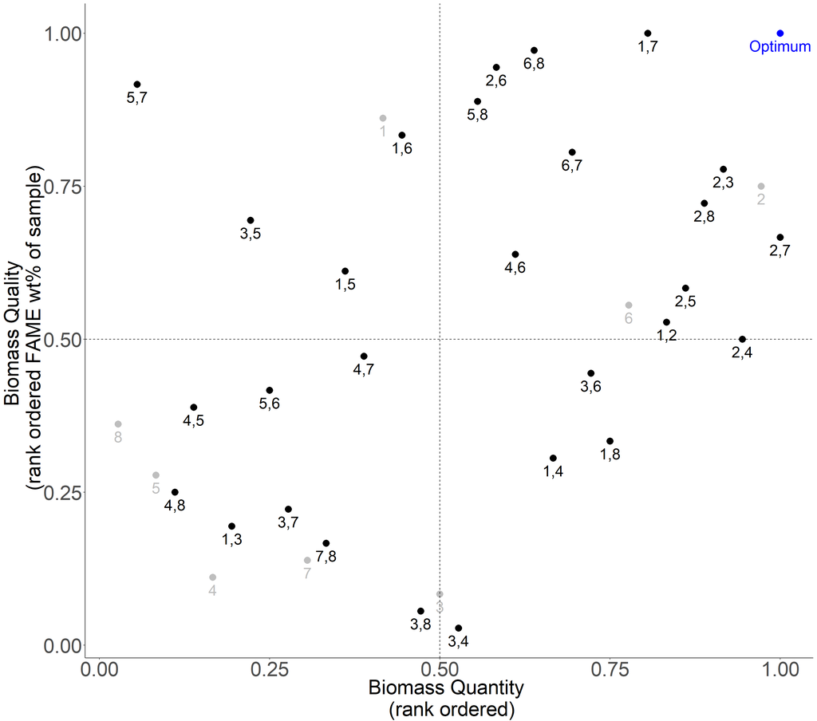

```r
library(ggplot2)
library(nlme)
library(gridExtra)
library(car)
library(MASS)
Biomass.FAME<-read.csv("C:/Users/Sara/Desktop/Biofuels Genomics Github/Total FAME x Biovolume.csv")
Biomass.FAME<-data.frame(Biomass.FAME$Euclidean.Distance,Biomass.FAME$DE.Lipids,Biomass.FAME$FAME.wt...,Biomass.FAME$Total.Culture.Biomass,Biomass.FAME$Total.Culture.Biomass.RANKED,Biomass.FAME$FAME.wt....RANKED,Biomass.FAME$Mono.v.Bi,Biomass.FAME$Treatment,Biomass.FAME$Fame.x.Biomass)
Biomass.FAME<-Biomass.FAME[!is.na(Biomass.FAME$Biomass.FAME.Total.Culture.Biomass.RANKED),]

Fig.1.part.1<-ggplot(Biomass.FAME,aes(Biomass.FAME.Total.Culture.Biomass.RANKED,Biomass.FAME.FAME.wt....RANKED,colour=Biomass.FAME.Mono.v.Bi,label=Biomass.FAME.Treatment))+
  geom_point(aes(size =3))+
  geom_text(aes(label=Biomass.FAME.Treatment),hjust=0.5,vjust=1.6,size=8)+
  theme(legend.text.align = 0,legend.key=element_rect(fill=NA),panel.grid.major = element_blank(), panel.grid.minor = element_blank(),panel.background = element_blank(), axis.line = element_line(colour = "black"),axis.text=element_text(size = 30),axis.title=element_text(size=30,face="plain"),legend.title=element_text(size=30),legend.text=element_text(size=30))+
  scale_colour_manual(values=c("black","grey","blue"),name="Culture",labels=c("Monoculture","Biculture","Optimum"),guide='none')+
  xlab("Biomass Quantity \n (rank ordered)")+
  ylab("Biomass Quality \n (rank ordered FAME wt% of sample)")+
  scale_size(guide="none")+
  geom_vline(xintercept = 0.5,linetype=2)+
  geom_hline(yintercept = 0.5,linetype=2)
Fig.1.part.1
```

```r
Biomass.FAME<-Biomass.FAME[1:36,1:9]

Biomass.FAME.raw<-read.csv("C:/Users/Sara/Desktop/Biofuels Genomics Github/Total FAME x Biovolume.csv")
Biomass.FAME.raw<-data.frame(Biomass.FAME.raw$FAME.wt....1,Biomass.FAME.raw$Total.Culture.Biomass.1,Biomass.FAME.raw$Total.Culture.FAMEs,Biomass.FAME.raw$Mono.v.Bi.2,Biomass.FAME.raw$Treatment.2,Biomass.FAME.raw$BoxCoxTotal.Culture.Biomass,Biomass.FAME.raw$BoxCox.Total.Culture.FAMEs)

#shapiro.test(Biomass.FAME.raw$Biomass.FAME.raw.Total.Culture.Biomass)
result<-aov(Biomass.FAME.raw.Total.Culture.Biomass.1~Biomass.FAME.raw.Mono.v.Bi.2,data=Biomass.FAME.raw)
#boxcox(result,lambda = seq(0, 0.4, 0.01))#use lambda = 0.25
result<-aov(Biomass.FAME.raw.Total.Culture.FAMEs~Biomass.FAME.raw.Mono.v.Bi.2,data=Biomass.FAME.raw)
#boxcox(result,lambda = seq(0, 0.4, 0.01))#use lambda = 0.2
#shapiro.test(Biomass.FAME.raw$Biomass.FAME.raw.BoxCox.Total.Culture.FAMEs)
#shapiro.test(Biomass.FAME.raw$Biomass.FAME.raw.BoxCoxTotal.Culture.Biomass)

summary(aov(Biomass.FAME.raw.BoxCoxTotal.Culture.Biomass~Biomass.FAME.raw.Mono.v.Bi.2/Biomass.FAME.raw.Treatment.2,data=Biomass.FAME.raw))
```

```
##                                                           Df Sum Sq
## Biomass.FAME.raw.Mono.v.Bi.2                               1   6431
## Biomass.FAME.raw.Mono.v.Bi.2:Biomass.FAME.raw.Treatment.2 34  74468
## Residuals                                                 71  35176
##                                                           Mean Sq F value
## Biomass.FAME.raw.Mono.v.Bi.2                                 6431  12.980
## Biomass.FAME.raw.Mono.v.Bi.2:Biomass.FAME.raw.Treatment.2    2190   4.421
## Residuals                                                     495
##                                                             Pr(>F)
## Biomass.FAME.raw.Mono.v.Bi.2                               0.00058 ***
## Biomass.FAME.raw.Mono.v.Bi.2:Biomass.FAME.raw.Treatment.2 6.58e-08 ***
## Residuals
## ---
## Signif. codes:  0 '***' 0.001 '**' 0.01 '*' 0.05 '.' 0.1 ' ' 1
```

```r
a<-ggplot(Biomass.FAME,aes(Biomass.FAME.Mono.v.Bi,Biomass.FAME.Total.Culture.Biomass))+
  geom_boxplot(aes(),outlier.shape=NA)+
  geom_jitter(aes(color = Biomass.FAME.Mono.v.Bi,size=3),width = 0.1)+
  theme(legend.text.align = 0,legend.key=element_rect(fill=NA),panel.grid.major = element_blank(), panel.grid.minor = element_blank(),panel.background = element_blank(), axis.line = element_line(colour = "black"),axis.text=element_text(size = 30),axis.title=element_text(size=30,face="plain"),legend.title=element_text(size=30),legend.text=element_text(size=30))+
  scale_colour_manual(values=c("black","grey"),name="Culture",labels=c("Monoculture","Biculture"),guide='none')+
  xlab("")+
  ylab("Biomass Quantity \n (ug/mL of biomass)\n")+
  scale_size(guide="none")

Biomass.FAME.raw.no.nas<-Biomass.FAME.raw[!is.na(Biomass.FAME.raw$Biomass.FAME.raw.FAME.wt....1),]
summary(aov(Biomass.FAME.raw.FAME.wt....1~Biomass.FAME.raw.Mono.v.Bi.2/Biomass.FAME.raw.Treatment.2,data=Biomass.FAME.raw.no.nas))
```

```
##                                                           Df  Sum Sq
## Biomass.FAME.raw.Mono.v.Bi.2                               1 0.01171
## Biomass.FAME.raw.Mono.v.Bi.2:Biomass.FAME.raw.Treatment.2 34 0.19443
## Residuals                                                 63 0.08018
##                                                            Mean Sq F value
## Biomass.FAME.raw.Mono.v.Bi.2                              0.011713   9.203
## Biomass.FAME.raw.Mono.v.Bi.2:Biomass.FAME.raw.Treatment.2 0.005719   4.493
## Residuals                                                 0.001273
##                                                             Pr(>F)
## Biomass.FAME.raw.Mono.v.Bi.2                               0.00351 **
## Biomass.FAME.raw.Mono.v.Bi.2:Biomass.FAME.raw.Treatment.2 1.32e-07 ***
## Residuals
## ---
## Signif. codes:  0 '***' 0.001 '**' 0.01 '*' 0.05 '.' 0.1 ' ' 1
```

```r
b<-ggplot(Biomass.FAME,aes(Biomass.FAME.Mono.v.Bi,Biomass.FAME.FAME.wt...))+
  geom_boxplot(aes(),outlier.shape=NA)+
  geom_jitter(aes(color = Biomass.FAME.Mono.v.Bi,size=3),width = 0.1)+
  theme(legend.text.align = 0,legend.key=element_rect(fill=NA),panel.grid.major = element_blank(), panel.grid.minor = element_blank(),panel.background = element_blank(), axis.line = element_line(colour = "black"),axis.text=element_text(size = 30),axis.title=element_text(size=30,face="plain"),legend.title=element_text(size=30),legend.text=element_text(size=30))+
  scale_colour_manual(values=c("black","grey"),name="Culture",labels=c("Monoculture","Biculture"),guide='none')+
  xlab("")+
  ylab("Biomass Quality \n (FAME wt% of sample)\n")+
  scale_size(guide="none")

summary(aov(Biomass.FAME.raw.BoxCox.Total.Culture.FAMEs~Biomass.FAME.raw.Mono.v.Bi.2/Biomass.FAME.raw.Treatment.2,data=Biomass.FAME.raw.no.nas))
```

```
##                                                           Df Sum Sq
## Biomass.FAME.raw.Mono.v.Bi.2                               1    381
## Biomass.FAME.raw.Mono.v.Bi.2:Biomass.FAME.raw.Treatment.2 34   4939
## Residuals                                                 63    904
##                                                           Mean Sq F value
## Biomass.FAME.raw.Mono.v.Bi.2                                381.2   26.56
## Biomass.FAME.raw.Mono.v.Bi.2:Biomass.FAME.raw.Treatment.2   145.3   10.12
## Residuals                                                    14.4
##                                                             Pr(>F)
## Biomass.FAME.raw.Mono.v.Bi.2                              2.74e-06 ***
## Biomass.FAME.raw.Mono.v.Bi.2:Biomass.FAME.raw.Treatment.2 4.09e-15 ***
## Residuals
## ---
## Signif. codes:  0 '***' 0.001 '**' 0.01 '*' 0.05 '.' 0.1 ' ' 1
```

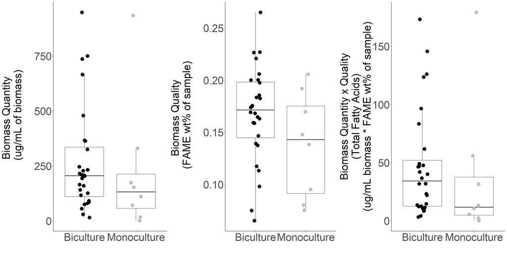

```r
c<-ggplot(Biomass.FAME,aes(Biomass.FAME.Mono.v.Bi,Biomass.FAME.Fame.x.Biomass))+
  geom_boxplot(aes(),outlier.shape=NA)+
  geom_jitter(aes(color = Biomass.FAME.Mono.v.Bi,size=3),width = 0.1)+
  theme(legend.text.align = 0,legend.key=element_rect(fill=NA),panel.grid.major = element_blank(), panel.grid.minor = element_blank(),panel.background = element_blank(), axis.line = element_line(colour = "black"),axis.text=element_text(size = 30),axis.title=element_text(size=30,face="plain"),legend.title=element_text(size=30),legend.text=element_text(size=30))+
  scale_colour_manual(values=c("black","grey"),name="Culture",labels=c("Monoculture","Biculture"),guide='none')+
  xlab("")+
  ylab("Biomass Quantity x Quality\n(Total Fatty Acids)\n(ug/mL biomass * FAME wt% of sample)")+
  scale_size(guide="none")

Fig.1.part.2<-grid.arrange(a,b,c,ncol=3)
```

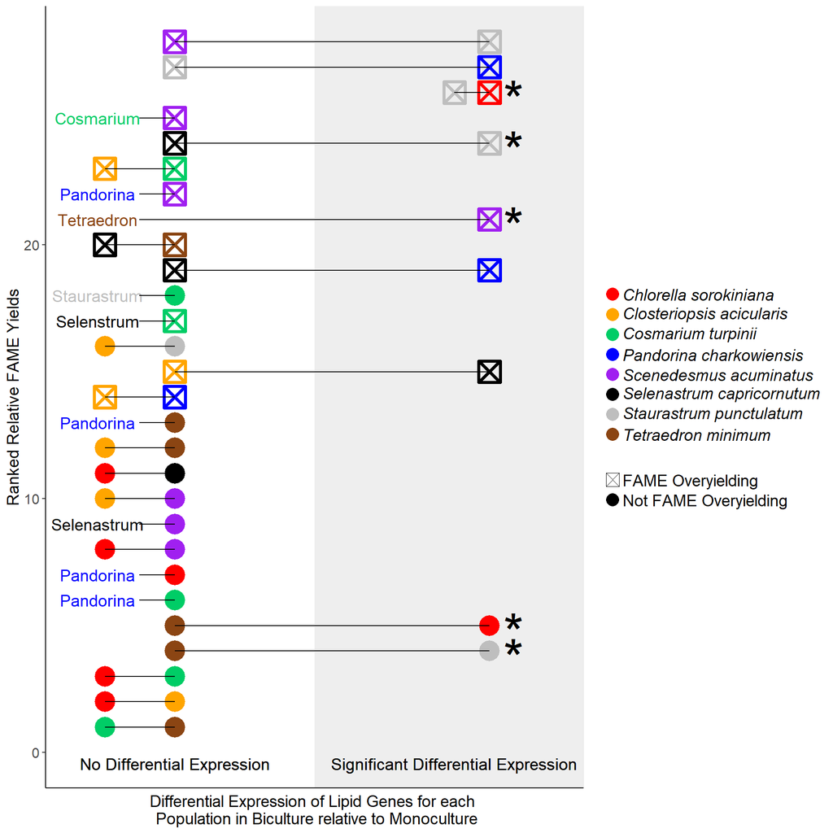

```r
competition.figure<-read.csv("C:/Users/Sara/Desktop/Biofuels Genomics Github/Competition.figure.csv")

my_expression1<-expression(paste(italic("Chlorella sorokiniana")))
my_expression2<-expression(paste(italic("Closteriopsis acicularis")))
my_expression3<-expression(paste(italic("Cosmarium turpinii")))
my_expression4<-expression(paste(italic("Pandorina charkowiensis")))
my_expression5<-expression(paste(italic("Scenedesmus acuminatus")))
my_expression6<-expression(paste(italic("Selenastrum capricornutum")))
my_expression7<-expression(paste(italic("Staurastrum punctulatum")))
my_expression8<-expression(paste(italic("Tetraedron minimum")))

competition.figure$Species<-as.factor(competition.figure$Species)
competition.figure$Overyielding.FAME <- factor(competition.figure$Overyielding.FAME, levels = rev(levels(competition.figure$Overyielding.FAME)))

Figure.2<-ggplot(competition.figure,aes(Simple.Sig.NS,Ranked.Combined.Relative.FAME.log2FC))+
  geom_rect(fill = "gray92", alpha = 0.15,aes(xmin=0.05,xmax=1.0,ymin=-5,ymax=35))+
  geom_point(aes(colour=Species,size=3,shape=Overyielding.FAME,stroke=2))+
  geom_line(aes(group = combo))+
  xlab("Differential Expression of Lipid Genes for each \n Population in Biculture relative to Monoculture")+
  ylab("Ranked Relative FAME Yields")+
  theme(axis.text.x=element_blank(),axis.ticks.x=element_blank(),legend.text.align = 0,legend.title.align=0.5,legend.key=element_rect(fill=NA),panel.grid.major = element_blank(), panel.grid.minor = element_blank(),panel.background = element_blank(), axis.line = element_line(colour = "black"),axis.text=element_text(size = 12),axis.title=element_text(size=14,face="plain"),legend.title=element_blank(),legend.text=element_text(size=14))+
  guides(color=guide_legend(override.aes=list(size=5)),shape=guide_legend(override.aes=list(size=5)))+
  scale_shape_manual(values=c("Yes"=7,"No"=16),labels=c("Yes"= "FAME Overyielding","No"="Not FAME Overyielding"))+
  scale_colour_manual(values=c("red","orange","springgreen3","blue","purple","black","gray","chocolate4"),labels=c(my_expression1,my_expression2,my_expression3,my_expression4,my_expression5,my_expression6,my_expression7,my_expression8),name = "Species")+
  scale_size(range = c(1,10),guide="none")+
  coord_cartesian(xlim=c(-0.02,0.12), ylim=c(0.00,28))+
  annotate ("text", x = 0.01, y = 0.02, label = "\nNo Differential Expression",size=5)+
  annotate("text",x=0.09,y=0.02, label = "\nSignificant Differential Expression",size=5)+
  annotate ("text", x = 0.01, y = 0.02, label = "\nNo Differential Expression",size=5)+
  annotate("text",x=0.09,y=0.02, label = "\nSignificant Differential Expression",size=5)+
  annotate("text",x=-0.012,y=25,label = "Cosmarium",size=5,colour="springgreen3")+
  annotate("segment", x = -0.0001, xend = 0.01, y = 25, yend = 25,colour = "black")+
  annotate("text",x=-0.012,y=22,label = "Pandorina",size=5,colour="blue")+
  annotate("segment", x = -0.0001, xend = 0.01, y = 22, yend = 22,colour = "black")+
  annotate("text",x=-0.012,y=21,label = "Tetraedron",size=5,colour="chocolate4")+
  annotate("segment", x = -0.0001, xend = 0.1, y = 21, yend = 21,colour = "black")+
  annotate("text",x=-0.012,y=18,label = "Staurastrum",size=5,colour="gray")+
  annotate("segment", x = -0.0001, xend = 0.01, y = 18, yend = 18,colour = "black")+
  annotate("text",x=-0.012,y=17,label = "Selenstrum",size=5,colour="black")+
  annotate("segment", x = -0.0001, xend = 0.01, y = 17, yend = 17,colour = "black")+
  annotate("text",x=-0.012,y=13,label = "Pandorina",size=5,colour="blue")+
  annotate("segment", x = -0.0001, xend = 0.01, y = 13, yend = 13,colour = "black")+
  annotate("text",x=-0.012,y=9,label = "Selenastrum",size=5,colour="black")+
  annotate("segment", x = -0.0001, xend = 0.01, y = 9, yend = 9,colour = "black")+
  annotate("text",x=-0.012,y=7,label = "Pandorina",size=5,colour="blue")+
  annotate("segment", x = -0.0001, xend = 0.01, y = 7, yend = 7,colour = "black")+
  annotate("text",x=-0.012,y=6,label = "Pandorina",size=5,colour="blue")+
  annotate("segment", x = -0.0001, xend = 0.01, y = 6, yend = 6,colour = "black")+
  annotate('text', x = 0.107, y = 3.75, label="*",size=16)+
  annotate('text', x = 0.107, y = 4.75, label='*',size=16)+
  annotate('text', x = 0.107, y = 25.75, label='*',size=16)+
  annotate('text', x = 0.107, y = 23.75, label='*',size=16)+
  annotate('text', x = 0.107, y = 20.75, label='*',size=16)

Figure.2
```

Fig. 3. Bicultures overyielding versus non-overyielding in FAME production exhibit notably distinct expression patterns of genes regulating synthesis and oxidation of fatty acids and other lipids. These patterns are conserved across multiple algal species. We illustrate these patterns via principal component analysis incorporating mean log2 fold change values in the monoculture versus biculture condition for each algal species of 28 different Gene Ontology groups involved in lipid regulatory functions.

```r
rm(list = ls())
library(ggplot2)
library(dplyr)
Aggregated.Go.Tables<-read.csv("C:/Users/Sara/Desktop/Biofuels Genomics Github/pca.csv",header=TRUE)
Aggregated.Go.Tables <- Aggregated.Go.Tables %>% mutate(FAME.Overyielding.2 = if_else(Biculture %in% c("logFC68","logFC86","logFC17","logFC71","logFC85","logFC58","logFC57","logFC75","logFC26","logFC62","logFC23","logFC32","logFC46","logFC64","logFC67","logFC76","logFC35","logFC53","logFC24","logFC42","logFC36","logFC63","logFC47","logFC74","logFC45","logFC54"), "Yes", "No"))
Aggregated.Go.Tables <- Aggregated.Go.Tables %>% mutate(Species = if_else(Biculture %in% c("logFC12","logFC13","logFC14","logFC15","logFC16","logFC17","logFC18"), "1",if_else(Biculture %in% c("logFC21","logFC23","logFC24","logFC25","logFC26","logFC27","logFC28"), "2",if_else(Biculture %in% c("logFC31","logFC32","logFC34","logFC35","logFC36","logFC37","logFC38"), "3",if_else(Biculture %in% c("logFC42","logFC43","logFC46","logFC47"), "4",if_else(Biculture %in% c("logFC51","logFC52","logFC53","logFC54","logFC56","logFC57","logFC58"), "5",if_else(Biculture %in% c ("logFC61","logFC62","logFC64","logFC67","logFC68"), "6",if_else(Biculture %in% c("logFC71","logFC72","logFC74","logFC75","logFC76","logFC78"), "7",if_else(Biculture %in% c("logFC81","logFC82","logFC83","logFC84","logFC86","logFC87"), "8","0")))))))))

Aggregated.Go.Tables <- Aggregated.Go.Tables %>% mutate(FAME.T.Overyielding = if_else(Biculture %in% c("logFC68","logFC17","logFC71","logFC58","logFC57","logFC75","logFC26","logFC62","logFC23","logFC32","logFC46","logFC64","logFC67","logFC76","logFC35","logFC53","logFC47","logFC74","logFC45","logFC54"), "Yes", "No"))
data<-Aggregated.Go.Tables[,1:29]
labels<-c(12,13,14,15,16,17,18,21,23,24,25,26,27,28,31,32,34,36,37,38,42,46,47,51,52,53,54,56,57,58,61,62,64,67,68,71,72,74,75,76,78,81,82,83,84,86,87)
row.names(data)<-labels
data$Biculture<-NULL
new.pca <- prcomp(data,center = TRUE)
Aggregated.Go.Tables$Species<-as.factor(Aggregated.Go.Tables$Species)
PC13<-new.pca$x[,1:3]
PC23<-new.pca$x[,2:3]
PC14<-new.pca$x[,1:4]
PC3<-new.pca$x[,3]
PC2<-new.pca$x[,2]
PC1<-new.pca$x[,1]

summary(manova(cbind(PC1,PC2,PC3)~Aggregated.Go.Tables$FAME.Overyielding+Aggregated.Go.Tables$Species))
```

```
##                                        Df  Pillai approx F num Df den Df
## Aggregated.Go.Tables$FAME.Overyielding  1 0.57133   15.993      3     36
## Aggregated.Go.Tables$Species            7 1.99504   10.777     21    114
## Residuals                              38
##                                           Pr(>F)
## Aggregated.Go.Tables$FAME.Overyielding 8.996e-07 ***
## Aggregated.Go.Tables$Species           < 2.2e-16 ***
## Residuals
## ---
## Signif. codes:  0 '***' 0.001 '**' 0.01 '*' 0.05 '.' 0.1 ' ' 1
```

```r
summary(aov(PC1~Aggregated.Go.Tables$FAME.Overyielding.2+Aggregated.Go.Tables$Species))
```

```
##                                          Df Sum Sq Mean Sq F value
## Aggregated.Go.Tables$FAME.Overyielding.2  1    3.7    3.67   1.089
## Aggregated.Go.Tables$Species              7  492.1   70.30  20.858
## Residuals                                38  128.1    3.37
##                                            Pr(>F)
## Aggregated.Go.Tables$FAME.Overyielding.2    0.303
## Aggregated.Go.Tables$Species             3.29e-11 ***
## Residuals
## ---
## Signif. codes:  0 '***' 0.001 '**' 0.01 '*' 0.05 '.' 0.1 ' ' 1
```

```r
summary(aov(PC2~Aggregated.Go.Tables$FAME.Overyielding.2+Aggregated.Go.Tables$Species))
```

```
##                                          Df Sum Sq Mean Sq F value
## Aggregated.Go.Tables$FAME.Overyielding.2  1  29.23  29.231   23.93
## Aggregated.Go.Tables$Species              7 103.50  14.786   12.10
## Residuals                                38  46.42   1.222
##                                            Pr(>F)
## Aggregated.Go.Tables$FAME.Overyielding.2 1.86e-05 ***
## Aggregated.Go.Tables$Species             5.23e-08 ***
## Residuals
## ---
## Signif. codes:  0 '***' 0.001 '**' 0.01 '*' 0.05 '.' 0.1 ' ' 1
```

```r
summary(aov(PC3~Aggregated.Go.Tables$FAME.Overyielding.2+Aggregated.Go.Tables$Species))
```

```
##                                          Df Sum Sq Mean Sq F value
## Aggregated.Go.Tables$FAME.Overyielding.2  1   1.76   1.755   1.556
## Aggregated.Go.Tables$Species              7  40.45   5.779   5.122
## Residuals                                38  42.87   1.128
##                                            Pr(>F)
## Aggregated.Go.Tables$FAME.Overyielding.2 0.219918
## Aggregated.Go.Tables$Species             0.000364 ***
## Residuals
## ---
## Signif. codes:  0 '***' 0.001 '**' 0.01 '*' 0.05 '.' 0.1 ' ' 1
```

```r
Aggregated.Go.Tables <- Aggregated.Go.Tables %>% mutate(FAME.Overyielding.3 = if_else(FAME.Overyielding.2 %in% c("Yes"), "1", "0"))
Aggregated.Go.Tables$FAME.Overyielding.3<-as.numeric(Aggregated.Go.Tables$FAME.Overyielding.3)

result<-glm(Aggregated.Go.Tables$FAME.Overyielding.3~PC1+PC2+PC3,family=binomial(link="logit"))
reduced<-glm(Aggregated.Go.Tables$FAME.Overyielding.3~PC2+PC3,family=binomial(link="logit"))
single<-glm(Aggregated.Go.Tables$FAME.Overyielding.3~PC2,family=binomial(link="logit"))
null<-glm(Aggregated.Go.Tables$FAME.Overyielding.3~1,family=binomial(link="logit"))
anova(null,reduced,test="Chisq")
```

```
## Analysis of Deviance Table
##
## Model 1: Aggregated.Go.Tables$FAME.Overyielding.3 ~ 1
## Model 2: Aggregated.Go.Tables$FAME.Overyielding.3 ~ PC2 + PC3
##   Resid. Df Resid. Dev Df Deviance Pr(>Chi)
## 1        46     64.964
## 2        44     54.231  2   10.733 0.004671 **
## ---
## Signif. codes:  0 '***' 0.001 '**' 0.01 '*' 0.05 '.' 0.1 ' ' 1
```

```r
anova(single,null,test="Chisq")
```

```
## Analysis of Deviance Table
##
## Model 1: Aggregated.Go.Tables$FAME.Overyielding.3 ~ PC2
## Model 2: Aggregated.Go.Tables$FAME.Overyielding.3 ~ 1
##   Resid. Df Resid. Dev Df Deviance Pr(>Chi)
## 1        45     55.585
## 2        46     64.964 -1  -9.3792 0.002195 **
## ---
## Signif. codes:  0 '***' 0.001 '**' 0.01 '*' 0.05 '.' 0.1 ' ' 1
```

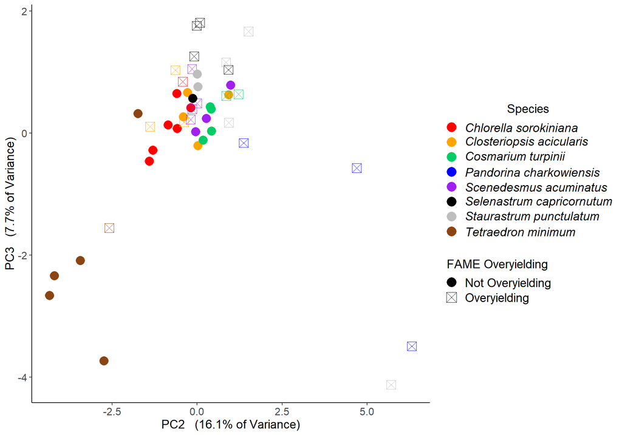

```r
my_expression<-expression(paste(italic("Chlorella sorokiniana")))
my_expression1<-expression(paste(italic("Closteriopsis acicularis")))
my_expression2<-expression(paste(italic("Cosmarium turpinii")))
my_expression3<-expression(paste(italic("Pandorina charkowiensis")))
my_expression4<-expression(paste(italic("Scenedesmus acuminatus")))
my_expression5<-expression(paste(italic("Selenastrum capricornutum")))
my_expression6<-expression(paste(italic("Staurastrum punctulatum")))
my_expression7<-expression(paste(italic("Tetraedron minimum")))
data<-cbind(new.pca$x,Aggregated.Go.Tables[,30:32],Aggregated.Go.Tables[,1])
data$Species<-as.factor(data$Species)

Figure.3<-ggplot(data, aes(PC2,PC3,colour=data$Species,shape=data$FAME.Overyielding,size=3))+
  geom_point()+
  theme(legend.text.align = 0,legend.title.align=0.5,legend.key=element_rect(fill=NA),panel.grid.major = element_blank(), panel.grid.minor = element_blank(),panel.background = element_blank(), axis.line = element_line(colour = "black"),axis.text=element_text(size = 12),axis.title=element_text(size=14,face="plain"),legend.title=element_text(size=14),legend.text=element_text(size=14))+
  guides(color=guide_legend(override.aes=list(size=5)),shape=guide_legend(override.aes=list(size=5)))+
  scale_shape_manual("FAME Overyielding",labels=c("Not Overyielding", "Overyielding"),values=c(16,7))+
  scale_colour_manual("Species",labels=c(my_expression,my_expression1,my_expression2,my_expression3,my_expression4,my_expression5,my_expression6,my_expression7),values=c("red","orange","springgreen3","blue","purple","black","gray","chocolate4"))+
  scale_size(guide="none")+
  xlab("PC2   (16.1% of Variance)")+
  ylab ("PC3   (7.7% of Variance)")
Figure.3
```

Fig.4. Across multiple species of algae, relative change in gene expression between monoculture and biculture growing conditions significantly predicts the relative change in FAMEs. Correlation between log2 fold change of gene expression and FAME in biculture relative to monoculture were evaluated via simple linear regression models with false discovery rate significance corrections. Orthologs in Chlorella variabilis are used for gene annotation when possible. Occasionally, we note orthologs from other model organisms from which we needed to infer gene annotation. For genes especially notable for fatty acid biosynthesis (DGATs and PDATs inferred from Arabidopsis thaliana), we show lack of correlation

```r
library(gridExtra)
library(ggplot2)
library(grid)
library(cowplot)

XP_005842867.1<-read.csv("C:/Users/Sara/Desktop/Biofuels Genomics Github/FAME_XP_005842867.1.csv")
XP_005848792.1<-read.csv("C:/Users/Sara/Desktop/Biofuels Genomics Github/FAME_XP_005848792.1.csv")
XP_005847875.1<-read.csv("C:/Users/Sara/Desktop/Biofuels Genomics Github/FAME_XP_005847875.1.csv")
XP_005850190.1<-read.csv("C:/Users/Sara/Desktop/Biofuels Genomics Github/FAME_XP_005850190.1.csv")
XP_005850208.1<-read.csv("C:/Users/Sara/Desktop/Biofuels Genomics Github/FAME_XP_005850208.1.csv")
XP_005842809.1<-read.csv("C:/Users/Sara/Desktop/Biofuels Genomics Github/FAME_XP_005842809.2.csv")

my_expression1<-expression(paste(italic("Chlorella sorokiniana")))
my_expression2<-expression(paste(italic("Closteriopsis acicularis")))
my_expression3<-expression(paste(italic("Cosmarium turpinii")))
my_expression4<-expression(paste(italic("Pandorina charkowiensis")))
my_expression5<-expression(paste(italic("Scenedesmus acuminatus")))
my_expression6<-expression(paste(italic("Selenastrum capricornutum")))
my_expression7<-expression(paste(italic("Staurastrum punctulatum")))
my_expression8<-expression(paste(italic("Tetraedron minimum")))

summary(lm(log2ratioofFAME~logFC,XP_005842867.1))
```

```
##
## Call:
## lm(formula = log2ratioofFAME ~ logFC, data = XP_005842867.1)
##
## Residuals:
##      Min       1Q   Median       3Q      Max
## -0.62253 -0.09149  0.02612  0.15931  0.53109
##
## Coefficients:
##             Estimate Std. Error t value Pr(>|t|)
## (Intercept)  0.49741    0.08941   5.563 2.79e-05 ***
## logFC        1.52742    0.22562   6.770 2.42e-06 ***
## ---
## Signif. codes:  0 '***' 0.001 '**' 0.01 '*' 0.05 '.' 0.1 ' ' 1
##
## Residual standard error: 0.3218 on 18 degrees of freedom
## Multiple R-squared:  0.718,  Adjusted R-squared:  0.7023
## F-statistic: 45.83 on 1 and 18 DF,  p-value: 2.422e-06
```

```r
XP_005842867.1.plot<-ggplot(XP_005842867.1,aes(logFC,log2ratioofFAME))+
  geom_point(aes(colour=factor(Species),shape=Overyielding,size=3)) +
  geom_smooth(method=lm,colour='black',fullrange=TRUE)+
  theme(legend.text.align = 0,legend.key=element_rect(fill=NA),panel.grid.major = element_blank(), panel.grid.minor = element_blank(),panel.background = element_blank(), axis.line = element_line(colour = "black"),axis.text=element_text(size = 12),axis.title=element_text(size=14,face="plain"),legend.title=element_text(size=12),legend.text=element_text(size=12))+
  xlab("Log2FC of E1ZTQ8_CHLVA (PEX16_ARATH) \n Peroxisome biogenesis protein 16 \n GO:Fatty Acid Biosynthetic Process")+
  ylab("FAME  (Log2FC)")+
  scale_colour_manual(guide="none","Algal Species",labels=c(my_expression1,my_expression2,my_expression7),values=c("red","orange","gray"))+
  scale_shape_manual(guide="none","FAME Overyielding",labels=c("Not Overyielding","Overyielding"),values=c(16,7))+
  scale_size(guide="none")+
  annotate("text", x=-0.95, y=1.75,label=paste("list(R^{2}==0.702)"),parse=TRUE,hjust=0.0,size=5)+
  scale_x_continuous(expand=c(0,0),limits=c(-5,5)) +
  scale_y_continuous(expand=c(0,0),limits=c(-5,5)) +
  coord_cartesian(xlim=c(-1,0.5), ylim=c(-1,2))

summary(lm(log2ratioofFAME~logFC,XP_005848792.1))
```

```
##
## Call:
## lm(formula = log2ratioofFAME ~ logFC, data = XP_005848792.1)
##
## Residuals:
##      Min       1Q   Median       3Q      Max
## -0.81774 -0.36377  0.05888  0.29884  0.88184
##
## Coefficients:
##             Estimate Std. Error t value Pr(>|t|)
## (Intercept)  0.28242    0.06715   4.206 0.000147 ***
## logFC       -0.34450    0.06814  -5.056 1.05e-05 ***
## ---
## Signif. codes:  0 '***' 0.001 '**' 0.01 '*' 0.05 '.' 0.1 ' ' 1
##
## Residual standard error: 0.4253 on 39 degrees of freedom
## Multiple R-squared:  0.3959, Adjusted R-squared:  0.3804
## F-statistic: 25.56 on 1 and 39 DF,  p-value: 1.05e-05
```

```r
XP_005848792.1.plot<-ggplot(XP_005848792.1,aes(logFC,log2ratioofFAME))+
  geom_point(aes(colour=factor(Species),shape=Overyielding,size=3)) +
  geom_smooth(method=lm,colour='black',fullrange=TRUE)+
  theme(legend.text.align = 0,legend.key=element_rect(fill=NA),panel.grid.major = element_blank(), panel.grid.minor = element_blank(),panel.background = element_blank(), axis.line = element_line(colour = "black"),axis.text=element_text(size = 12),axis.title=element_text(size=14,face="plain"),legend.title=element_text(size=12),legend.text=element_text(size=12))+
  xlab("Log2FC of E1ZDY1_CHLVA \n Lysophospholipid acyltransferase (LPLAT-AGPAT-like) \n GO: Phospholipid Biosynthetic Process")+
  ylab("FAME  (Log2FC)")+
  annotate("text", x=0.25, y=1.75,label=paste("list(R^{2}==0.38)"),parse=TRUE,hjust=0.0,size=5)+
  scale_colour_manual(guide='none',"Algal Species",labels=c(my_expression1,my_expression2,my_expression3,my_expression4,my_expression5,my_expression6,my_expression7),values=c("red","orange","springgreen3","blue","purple","black","gray"))+
  scale_shape_manual(guide='none',"FAME Overyielding",labels=c("Not Overyielding","Overyielding"),values=c(16,7))+
  scale_size(guide="none")+
  scale_x_continuous(expand=c(0,0),limits=c(-5,5)) +
  scale_y_continuous(expand=c(0,0),limits=c(-5,5)) +
  coord_cartesian(xlim=c(-4.5,1.5), ylim=c(-1,2))

summary(lm(log2ratioofFAME~logFC,XP_005847875.1))
```

```
##
## Call:
## lm(formula = log2ratioofFAME ~ logFC, data = XP_005847875.1)
##
## Residuals:
##      Min       1Q   Median       3Q      Max
## -1.06347 -0.11335 -0.03976  0.24764  0.47271
##
## Coefficients:
##             Estimate Std. Error t value Pr(>|t|)
## (Intercept)  0.18670    0.07473   2.498 0.021304 *
## logFC       -0.27448    0.05687  -4.826 0.000103 ***
## ---
## Signif. codes:  0 '***' 0.001 '**' 0.01 '*' 0.05 '.' 0.1 ' ' 1
##
## Residual standard error: 0.3432 on 20 degrees of freedom
## Multiple R-squared:  0.538,  Adjusted R-squared:  0.515
## F-statistic: 23.29 on 1 and 20 DF,  p-value: 0.0001025
```

```r
XP_005847875.1.plot<-ggplot(XP_005847875.1,aes(logFC,log2ratioofFAME))+
  geom_point(aes(colour=factor(Species),shape=Overyielding,size=3)) +
  geom_smooth(method=lm,colour='black',fullrange=TRUE)+
  theme(legend.text.align = 0,legend.key=element_rect(fill=NA),panel.grid.major = element_blank(), panel.grid.minor = element_blank(),panel.background = element_blank(), axis.line = element_line(colour = "black"),axis.text=element_text(size = 12),axis.title=element_text(size=14,face="plain"),legend.title=element_text(size=12),legend.text=element_text(size=12))+
  xlab("Log2FC of E1Z750_CHLVA \n Phospholipid-transporting ATPase \n GO: Phospholipid Metabolic Process")+
  ylab("FAME  (Log2FC)")+
  annotate("text", x=0.8, y=1.4,label=paste("list(R^{2}==0.51)"),parse=TRUE,hjust=0.0,size=5)+
  scale_colour_manual(guide="none","Algal Species",labels=c(my_expression1,my_expression4,my_expression5,my_expression6),values=c("red","blue","purple","black"))+
  scale_shape_manual(guide="none","FAME Overyielding",labels=c("Not Overyielding","Overyielding"),values=c(16,7))+
  scale_size(guide="none")+
  scale_x_continuous(expand=c(0,0),limits=c(-15,15)) +
  scale_y_continuous(expand=c(0,0),limits=c(-15,15)) +
  coord_cartesian(xlim=c(-4,2), ylim=c(-1,1.5))

summary(lm(log2ratioofFAME~logFC,XP_005850190.1))
```

```
##
## Call:
## lm(formula = log2ratioofFAME ~ logFC, data = XP_005850190.1)
##
## Residuals:
##      Min       1Q   Median       3Q      Max
## -0.82172 -0.18336  0.08737  0.16757  0.43062
##
## Coefficients:
##             Estimate Std. Error t value Pr(>|t|)
## (Intercept)  0.36734    0.09468   3.880 0.002188 **
## logFC       -1.03090    0.19935  -5.171 0.000233 ***
## ---
## Signif. codes:  0 '***' 0.001 '**' 0.01 '*' 0.05 '.' 0.1 ' ' 1
##
## Residual standard error: 0.3483 on 12 degrees of freedom
## Multiple R-squared:  0.6903, Adjusted R-squared:  0.6645
## F-statistic: 26.74 on 1 and 12 DF,  p-value: 0.0002326
```

```r
XP_005850190.1.plot<-ggplot(XP_005850190.1,aes(logFC,log2ratioofFAME))+
  geom_point(aes(colour=factor(Species),shape=Overyielding,size=3)) +
  geom_smooth(method=lm,colour='black',fullrange=TRUE)+
  theme(legend.text.align = 0,legend.key=element_rect(fill=NA),panel.grid.major = element_blank(), panel.grid.minor = element_blank(),panel.background = element_blank(), axis.line = element_line(colour = "black"),axis.text=element_text(size = 12),axis.title=element_text(size=14,face="plain"),legend.title=element_text(size=12),legend.text=element_text(size=12))+
  xlab("Log2FC of E1ZBS3_CHLVA \n CDP-diacylglycerol-glycerol\n-3-phosphate 3-phosphatidyltransferase \n GO: Protein Lipidation")+
  ylab("FAME  (Log2FC)")+
  annotate("text", x=0.5, y=1.2,label=paste("list(R^{2}==0.66)"),parse=TRUE,hjust=0.0,size=5)+
  scale_colour_manual(guide="none","Algal Species",labels=c(my_expression4,my_expression6,my_expression8),values=c("blue","black","chocolate4"))+
  scale_shape_manual(guide="none","FAME Overyielding",labels=c("Not Overyielding","Overyielding"),values=c(16,7))+
  scale_size(guide="none")+
  scale_x_continuous(expand=c(0,0),limits=c(-5,5)) +
  scale_y_continuous(expand=c(0,0),limits=c(-5,5)) +
  coord_cartesian(xlim=c(-1.5,1.2), ylim=c(-1.5,1.5))

summary(lm(log2ratioofFAME~logFC,XP_005850208.1))
```

```
##
## Call:
## lm(formula = log2ratioofFAME ~ logFC, data = XP_005850208.1)
##
## Residuals:
##      Min       1Q   Median       3Q      Max
## -0.87219 -0.34619  0.01771  0.34201  0.76191
##
## Coefficients:
##             Estimate Std. Error t value Pr(>|t|)
## (Intercept)  0.37964    0.07254   5.234 6.39e-06 ***
## logFC        0.71090    0.17626   4.033 0.000256 ***
## ---
## Signif. codes:  0 '***' 0.001 '**' 0.01 '*' 0.05 '.' 0.1 ' ' 1
##
## Residual standard error: 0.458 on 38 degrees of freedom
## Multiple R-squared:  0.2998, Adjusted R-squared:  0.2813
## F-statistic: 16.27 on 1 and 38 DF,  p-value: 0.0002558
```

```r
my_grob = grobTree(textGrob(bquote(Adjusted~R^2 == .(paste(round(28.1333504, 2)))), x=0.65,  y=0.90, hjust=0, gp=gpar(col="black", fontsize=12, fontface="italic")))
XP_005850208.1.plot<-ggplot(XP_005850208.1,aes(logFC,log2ratioofFAME))+
  geom_point(aes(colour=factor(Species),shape=Overyielding,size=3)) +
  geom_smooth(method=lm,colour='black',fullrange=TRUE)+
  theme(legend.text.align = 0,legend.key=element_rect(fill=NA),panel.grid.major = element_blank(), panel.grid.minor = element_blank(),panel.background = element_blank(), axis.line = element_line(colour = "black"),axis.text=element_text(size = 12),axis.title=element_text(size=14,face="plain"),legend.title=element_text(size=12),legend.text=element_text(size=12))+
  xlab("Log2FC of E1Z8G6_CHLVA (A8I0Q7_CHLRE) \n Phosphatidylinositol kinase \n GO: Phospholipid-transporting ATPase")+
  ylab("FAME  (Log2FC)")+
  annotate("text", x=0.5, y=1.7,label=paste("list(R^{2}==0.28)"),parse=TRUE,hjust=0.0,size=5)+
  scale_colour_manual(guide="none","Algal Species",labels=c(my_expression2,my_expression3,my_expression4,my_expression5,my_expression6,my_expression7,my_expression8),values=c("orange","springgreen3","blue","purple","black","gray","chocolate4"))+
  scale_shape_manual(guide="none","FAME Overyielding",labels=c("Not Overyielding","Overyielding"),values=c(16,7))+
  scale_size(guide="none")+
  scale_x_continuous(expand=c(0,0),limits=c(-5,5)) +
  scale_y_continuous(expand=c(0,0),limits=c(-5,5)) +
  coord_cartesian(xlim=c(-1.5,1.0), ylim=c(-1.1,2))

summary(lm(log2ratioofFAME~logFC,XP_005842809.1))
```

```
##
## Call:
## lm(formula = log2ratioofFAME ~ logFC, data = XP_005842809.1)
##
## Residuals:
##      Min       1Q   Median       3Q      Max
## -1.42878 -0.28990 -0.03738  0.44848  0.97193
##
## Coefficients:
##             Estimate Std. Error t value Pr(>|t|)
## (Intercept)   0.1635     0.2359   0.693    0.498
## logFC         0.6289     0.4183   1.503    0.152
##
## Residual standard error: 0.651 on 16 degrees of freedom
## Multiple R-squared:  0.1238, Adjusted R-squared:  0.06903
## F-statistic:  2.26 on 1 and 16 DF,  p-value: 0.1522
```

```r
XP_005842809.1.plot<-ggplot(XP_005842809.1,aes(logFC,log2ratioofFAME))+
  geom_point(aes(colour=factor(Species),shape=Overyielding,size=3)) +
  theme(legend.text.align = 0,legend.key=element_rect(fill=NA),panel.grid.major = element_blank(), panel.grid.minor = element_blank(),panel.background = element_blank(), axis.line = element_line(colour = "black"),axis.text=element_text(size = 12),axis.title=element_text(size=14,face="plain"),legend.title=element_text(size=12),legend.text=element_text(size=12))+
  xlab("Log2FC of E1ZTZ7_CHLVA \n acyl CoA:diacylglycerol acyltransferase \n GO: Triglyceride biosynthesis")+
  ylab("FAME  (Log2FC)")+
  scale_colour_manual(guide="none","Algal Species",labels=c(my_expression3,my_expression7,my_expression8),values=c("springgreen3","gray","chocolate4"))+
  scale_shape_manual(guide="none","FAME Overyielding",labels=c("Not Overyielding","Overyielding"),values=c(16,7))+
  scale_size(guide="none")+
  annotate("text", x=0.7, y=1.7,label="NS",parse=TRUE,hjust=0.0,size=5)+
  scale_x_continuous(expand=c(0,0),limits=c(-5,5)) +
  scale_y_continuous(expand=c(0,0),limits=c(-5,5)) +
  coord_cartesian(xlim=c(-0.3,1.0), ylim=c(-1.1,2))

DGAT<-read.csv("C:/Users/Sara/Desktop/Biofuels Genomics Github/Arabidopsis_PDAT_and_DGAT_figures.csv")
summary(lm(log2ratioofFAME~logFC_DGAT,data=DGAT))
```

```
##
## Call:
## lm(formula = log2ratioofFAME ~ logFC_DGAT, data = DGAT)
##
## Residuals:
##     Min      1Q  Median      3Q     Max
## -1.2717 -0.3501 -0.0369  0.3548  1.1687
##
## Coefficients:
##             Estimate Std. Error t value Pr(>|t|)
## (Intercept)  0.25816    0.08837   2.921  0.00544 **
## logFC_DGAT   0.07879    0.15278   0.516  0.60856
## ---
## Signif. codes:  0 '***' 0.001 '**' 0.01 '*' 0.05 '.' 0.1 ' ' 1
##
## Residual standard error: 0.5654 on 45 degrees of freedom
## Multiple R-squared:  0.005876,   Adjusted R-squared:  -0.01622
## F-statistic: 0.266 on 1 and 45 DF,  p-value: 0.6086
```

```r
DGAT.plot<-ggplot(DGAT,aes(logFC_DGAT,log2ratioofFAME))+
  geom_point(aes(colour=factor(Species),shape=Overyielding,size=3)) +
  theme(legend.text.align = 0,legend.key=element_rect(fill=NA),panel.grid.major = element_blank(), panel.grid.minor = element_blank(),panel.background = element_blank(), axis.line = element_line(colour = "black"),axis.text=element_text(size = 12),axis.title=element_text(size=14,face="plain"),legend.title=element_text(size=12),legend.text=element_text(size=12))+
  xlab("Log2FC of DGAT1_CHLVA \n acyl CoA:diacylglycerol acyltransferase \n GO: Triglyceride biosynthesis")+
  ylab("FAME  (Log2FC)")+
  scale_colour_manual(guide='none',"Algal Species",labels=c(my_expression1,my_expression2,my_expression3,my_expression4,my_expression5,my_expression6,my_expression7,my_expression8),values=c("red","orange","springgreen3","blue","purple","black","gray","chocolate4"))+
  scale_shape_manual(guide='none',"FAME Overyielding",labels=c("Not Overyielding","Overyielding"),values=c(16,7))+
  scale_size(guide="none")+
  scale_x_continuous(expand=c(0,0),limits=c(-5,5)) +
  scale_y_continuous(expand=c(0,0),limits=c(-5,5)) +
  coord_cartesian(xlim=c(-1.5,1.75), ylim=c(-1.75,1.75))+
  annotate("text", x=1.25, y=1.4,label="NS",parse=TRUE,hjust=0.0,size=5)

summary(lm(log2ratioofFAME~logFC_PDAT,data=DGAT))
```

```
##
## Call:
## lm(formula = log2ratioofFAME ~ logFC_PDAT, data = DGAT)
##
## Residuals:
##      Min       1Q   Median       3Q      Max
## -1.43253 -0.25650 -0.04263  0.33776  1.03095
##
## Coefficients:
##             Estimate Std. Error t value Pr(>|t|)
## (Intercept)  0.45411    0.09939   4.569 7.36e-05 ***
## logFC_PDAT  -0.01624    0.09956  -0.163    0.871
## ---
## Signif. codes:  0 '***' 0.001 '**' 0.01 '*' 0.05 '.' 0.1 ' ' 1
##
## Residual standard error: 0.5506 on 31 degrees of freedom
##   (14 observations deleted due to missingness)
## Multiple R-squared:  0.0008581,  Adjusted R-squared:  -0.03137
## F-statistic: 0.02663 on 1 and 31 DF,  p-value: 0.8714
```

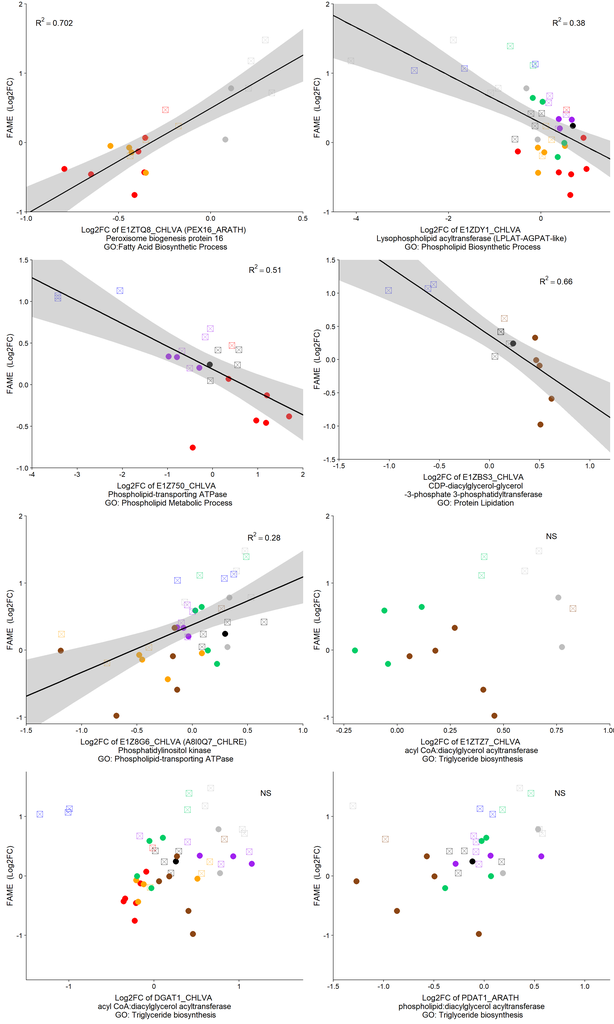

```r
DGAT<-DGAT[!is.na(DGAT$Pvalue_PDAT),]
PDAT.plot<-ggplot(DGAT,aes(logFC_PDAT,log2ratioofFAME))+
  geom_point(aes(colour=factor(Species),shape=Overyielding,size=3)) +
  theme(legend.text.align = 0,legend.key=element_rect(fill=NA),panel.grid.major = element_blank(), panel.grid.minor = element_blank(),panel.background = element_blank(), axis.line = element_line(colour = "black"),axis.text=element_text(size = 12),axis.title=element_text(size=14,face="plain"),legend.title=element_text(size=12),legend.text=element_text(size=12))+
  xlab("Log2FC of PDAT1_ARATH \n phospholipid:diacylglycerol acyltransferase \n GO: Triglyceride biosynthesis")+
  ylab("FAME  (Log2FC)")+
  scale_colour_manual(guide='none',"Algal Species",labels=c(my_expression3,my_expression4,my_expression5,my_expression6,my_expression7,my_expression8),values=c("springgreen3","blue","purple","black","gray","chocolate4"))+
  scale_shape_manual(guide='none',"FAME Overyielding",labels=c("Not Overyielding","Overyielding"),values=c(16,7))+
  scale_size(guide="none")+
  scale_x_continuous(expand=c(0,0),limits=c(-5,5)) +
  scale_y_continuous(expand=c(0,0),limits=c(-5,5)) +
  coord_cartesian(xlim=c(-1.5,1.25), ylim=c(-1.75,1.75))+
  annotate("text", x=0.7, y=1.4,label="NS",parse=TRUE,hjust=0.0,size=5)

Figure.4<-plot_grid(XP_005842867.1.plot,XP_005848792.1.plot,XP_005847875.1.plot,XP_005850190.1.plot,XP_005850208.1.plot,XP_005842809.1.plot,DGAT.plot,PDAT.plot,ncol=2,nrow=4)
Figure.4
```

## Supplementary Materials

Section 1: Alternative averaging approach for calculating multifunctionality also indicates bicultures outperform monocultures.

Figure S1 There are several approaches for calculating multifunctionality. (a) Here, we show that a higher percentage of bicultures versus monocultures simultaneously exceed thresholds for biomass yield and quality. (b) Additionally, we find that bicultures outperform monocultures via the averaging multifunctionality metric. We calculated this averaging multifunctionality index where FAME (wt % of samples) and Biomass (i.e., log transformed values of population cell density multiplied by estimates of cell biovolume) values were standardized via conversion to z-scores, and the FAME and Biomass standard scores were then averaged together to yield a multifunctionality value. Averaged multifunctionality index values across biological replicates are shown. Note the nested ANOVA uses all biological replicates with species combination nested within species richness.

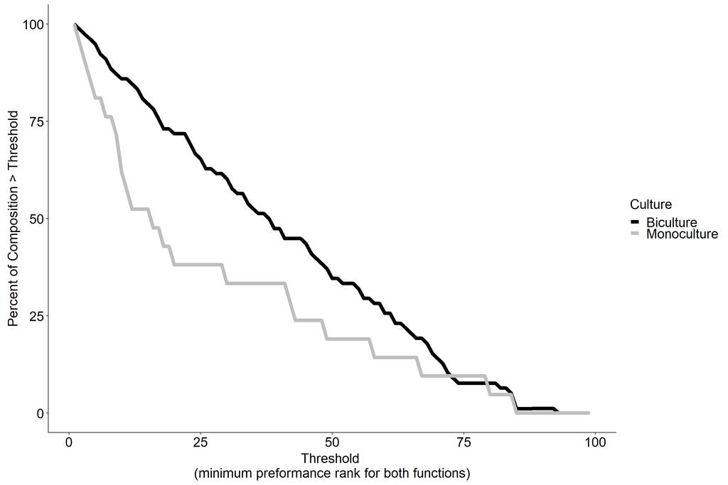

```r
Threshold.Approach.Multifunctionality<-read.csv("C:/Users/Sara/Desktop/Biofuels Genomics Github/multifunctionality.csv")
data<-data.frame(Threshold.Approach.Multifunctionality$Threshold,Threshold.Approach.Multifunctionality$Culture,Threshold.Approach.Multifunctionality$Percent.Cultures.Above.Threshold)
Figure.S1.A<-ggplot(data,aes(Threshold.Approach.Multifunctionality.Threshold,Threshold.Approach.Multifunctionality.Percent.Cultures.Above.Threshold,colour=Threshold.Approach.Multifunctionality.Culture))+
  geom_line(size=2.5)+
  theme(legend.text.align = 0,legend.key=element_rect(fill=NA),panel.grid.major = element_blank(), panel.grid.minor = element_blank(),panel.background = element_blank(), axis.line = element_line(colour = "black"),axis.text=element_text(size = 20),axis.title=element_text(size=20,face="plain"),legend.title=element_text(size=20),legend.text=element_text(size=20))+
  scale_colour_manual(values=c(Monoculture="grey",Biculture="black"),name="Culture")+
  xlab("Threshold \n(minimum preformance rank for both functions)")+
  ylab("Percent of Composition > Threshold")
Figure.S1.A
```

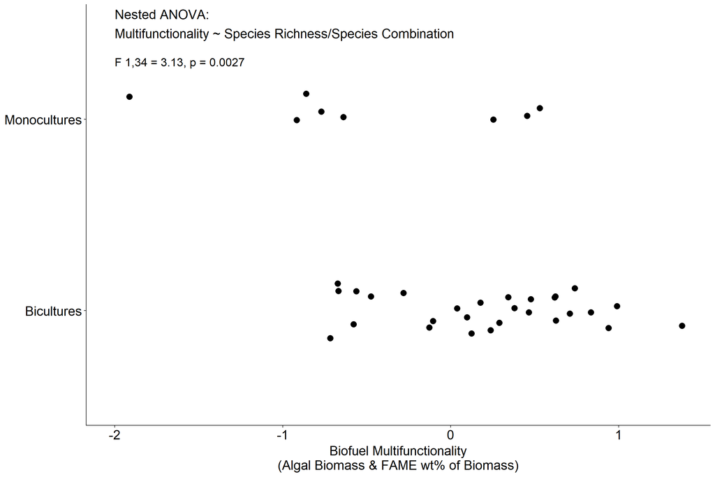

```r
Biomass.FAME<-read.csv("C:/Users/Sara/Desktop/Biofuels Genomics Github/Total FAME x Biovolume.csv")
Biomass.FAME<-data.frame(Biomass.FAME$Treatment.1,Biomass.FAME$Avg.Multifunctionality,Biomass.FAME$Mono.v.Bi.1,Biomass.FAME$Avg.Multifunctionality.SE,Biomass.FAME$Lipid.DE)
Biomass.FAME<-Biomass.FAME[!is.na(Biomass.FAME$Biomass.FAME.Avg.Multifunctionality),]
Figure.S1.B<-ggplot(Biomass.FAME,aes(Biomass.FAME.Avg.Multifunctionality,Biomass.FAME.Mono.v.Bi.1))+
  geom_jitter(height=0.15,size=4)+
  #geom_jitter(aes(size=3),height = 0.15) +
  theme(axis.title.y=element_blank(),legend.text.align = 0,legend.key=element_rect(fill=NA),panel.grid.major = element_blank(), panel.grid.minor = element_blank(),panel.background = element_blank(), axis.line = element_line(colour = "black"),axis.text=element_text(size = 16),axis.title=element_text(size=18,face="plain"),legend.title=element_text(size=16),legend.text=element_text(size=16))+
  theme(legend.text.align = 0,legend.key=element_rect(fill=NA),panel.grid.major = element_blank(), panel.grid.minor = element_blank(),panel.background = element_blank(), axis.line = element_line(colour = "black"),axis.text=element_text(size = 20),axis.title=element_text(size=20,face="plain"),legend.title=element_text(size=20),legend.text=element_text(size=20))+
  ylab("Culture")+
  xlab("Biofuel Multifunctionality\n(Algal Biomass & FAME wt% of Biomass)")+
  scale_size(guide="none")+
  annotate("text", size = 7, x=-2, y=2.5, label= "Nested ANOVA:\nMultifunctionality ~ Species Richness/Species Combination",hjust = 0.0)+
  annotate("text", size = 6, x=-2, y=2.3, label= "F 1,34 = 3.13, p = 0.0027",hjust = 0.0)
Figure.S1.B
```

Section 3: Supplementary PCA data illustrating genomic distinctions between populations belonging to FAME overyielding versus non-overyielding bicultures.

Figure S2 In addition to Fig. 3, here we show PC1 versus PC2 of our principal component analysis that incorporates mean log2FC values for each algal species of 28 different Gene Ontology groups involved in lipid regulatory functions. Note PC1 is largely differences across species, while PC2 and PC3 shown in Fig. 3 more clearly illustrate that bicultures overyielding versus non-overyielding in FAME production exhibit distinct patterns of gene expression.

```r
rm(list = ls())
library(ggplot2)
library(dplyr)
Aggregated.Go.Tables<-read.csv("C:/Users/Sara/Desktop/Biofuels Genomics Github/pca.csv",header=TRUE)
Aggregated.Go.Tables <- Aggregated.Go.Tables %>% mutate(FAME.Overyielding.2 = if_else(Biculture %in% c("logFC68","logFC86","logFC17","logFC71","logFC85","logFC58","logFC57","logFC75","logFC26","logFC62","logFC23","logFC32","logFC46","logFC64","logFC67","logFC76","logFC35","logFC53","logFC24","logFC42","logFC36","logFC63","logFC47","logFC74","logFC45","logFC54"), "Yes", "No"))
Aggregated.Go.Tables <- Aggregated.Go.Tables %>% mutate(Species = if_else(Biculture %in% c("logFC12","logFC13","logFC14","logFC15","logFC16","logFC17","logFC18"), "1",if_else(Biculture %in% c("logFC21","logFC23","logFC24","logFC25","logFC26","logFC27","logFC28"), "2",if_else(Biculture %in% c("logFC31","logFC32","logFC34","logFC35","logFC36","logFC37","logFC38"), "3",if_else(Biculture %in% c("logFC42","logFC43","logFC46","logFC47"), "4",if_else(Biculture %in% c("logFC51","logFC52","logFC53","logFC54","logFC56","logFC57","logFC58"), "5",if_else(Biculture %in% c ("logFC61","logFC62","logFC64","logFC67","logFC68"), "6",if_else(Biculture %in% c("logFC71","logFC72","logFC74","logFC75","logFC76","logFC78"), "7",if_else(Biculture %in% c("logFC81","logFC82","logFC83","logFC84","logFC86","logFC87"), "8","0")))))))))

Aggregated.Go.Tables <- Aggregated.Go.Tables %>% mutate(FAME.T.Overyielding = if_else(Biculture %in% c("logFC68","logFC17","logFC71","logFC58","logFC57","logFC75","logFC26","logFC62","logFC23","logFC32","logFC46","logFC64","logFC67","logFC76","logFC35","logFC53","logFC47","logFC74","logFC45","logFC54"), "Yes", "No"))
data<-Aggregated.Go.Tables[,1:29]
labels<-c(12,13,14,15,16,17,18,21,23,24,25,26,27,28,31,32,34,36,37,38,42,46,47,51,52,53,54,56,57,58,61,62,64,67,68,71,72,74,75,76,78,81,82,83,84,86,87)
row.names(data)<-labels
data$Biculture<-NULL
new.pca <- prcomp(data,center = TRUE)
Aggregated.Go.Tables$Species<-as.factor(Aggregated.Go.Tables$Species)
PC13<-new.pca$x[,1:3]
PC23<-new.pca$x[,2:3]
PC14<-new.pca$x[,1:4]
PC3<-new.pca$x[,3]
PC2<-new.pca$x[,2]
PC1<-new.pca$x[,1]

summary(manova(cbind(PC1,PC2,PC3)~Aggregated.Go.Tables$FAME.Overyielding+Aggregated.Go.Tables$Species))
```

```
##                                        Df  Pillai approx F num Df den Df
## Aggregated.Go.Tables$FAME.Overyielding  1 0.57133   15.993      3     36
## Aggregated.Go.Tables$Species            7 1.99504   10.777     21    114
## Residuals                              38
##                                           Pr(>F)
## Aggregated.Go.Tables$FAME.Overyielding 8.996e-07 ***
## Aggregated.Go.Tables$Species           < 2.2e-16 ***
## Residuals
## ---
## Signif. codes:  0 '***' 0.001 '**' 0.01 '*' 0.05 '.' 0.1 ' ' 1
```

```r
summary(aov(PC1~Aggregated.Go.Tables$FAME.Overyielding.2+Aggregated.Go.Tables$Species))
```

```
##                                          Df Sum Sq Mean Sq F value
## Aggregated.Go.Tables$FAME.Overyielding.2  1    3.7    3.67   1.089
## Aggregated.Go.Tables$Species              7  492.1   70.30  20.858
## Residuals                                38  128.1    3.37
##                                            Pr(>F)
## Aggregated.Go.Tables$FAME.Overyielding.2    0.303
## Aggregated.Go.Tables$Species             3.29e-11 ***
## Residuals
## ---
## Signif. codes:  0 '***' 0.001 '**' 0.01 '*' 0.05 '.' 0.1 ' ' 1
```

```r
summary(aov(PC2~Aggregated.Go.Tables$FAME.Overyielding.2+Aggregated.Go.Tables$Species))
```

```
##                                          Df Sum Sq Mean Sq F value
## Aggregated.Go.Tables$FAME.Overyielding.2  1  29.23  29.231   23.93
## Aggregated.Go.Tables$Species              7 103.50  14.786   12.10
## Residuals                                38  46.42   1.222
##                                            Pr(>F)
## Aggregated.Go.Tables$FAME.Overyielding.2 1.86e-05 ***
## Aggregated.Go.Tables$Species             5.23e-08 ***
## Residuals
## ---
## Signif. codes:  0 '***' 0.001 '**' 0.01 '*' 0.05 '.' 0.1 ' ' 1
```

```r
summary(aov(PC3~Aggregated.Go.Tables$FAME.Overyielding.2+Aggregated.Go.Tables$Species))
```

```
##                                          Df Sum Sq Mean Sq F value
## Aggregated.Go.Tables$FAME.Overyielding.2  1   1.76   1.755   1.556
## Aggregated.Go.Tables$Species              7  40.45   5.779   5.122
## Residuals                                38  42.87   1.128
##                                            Pr(>F)
## Aggregated.Go.Tables$FAME.Overyielding.2 0.219918
## Aggregated.Go.Tables$Species             0.000364 ***
## Residuals
## ---
## Signif. codes:  0 '***' 0.001 '**' 0.01 '*' 0.05 '.' 0.1 ' ' 1
```

```r
Aggregated.Go.Tables <- Aggregated.Go.Tables %>% mutate(FAME.Overyielding.3 = if_else(FAME.Overyielding.2 %in% c("Yes"), "1", "0"))
Aggregated.Go.Tables$FAME.Overyielding.3<-as.numeric(Aggregated.Go.Tables$FAME.Overyielding.3)

result<-glm(Aggregated.Go.Tables$FAME.Overyielding.3~PC1+PC2+PC3,family=binomial(link="logit"))
reduced<-glm(Aggregated.Go.Tables$FAME.Overyielding.3~PC2+PC3,family=binomial(link="logit"))
single<-glm(Aggregated.Go.Tables$FAME.Overyielding.3~PC2,family=binomial(link="logit"))
null<-glm(Aggregated.Go.Tables$FAME.Overyielding.3~1,family=binomial(link="logit"))
anova(null,reduced,test="Chisq")
```

```
## Analysis of Deviance Table
##
## Model 1: Aggregated.Go.Tables$FAME.Overyielding.3 ~ 1
## Model 2: Aggregated.Go.Tables$FAME.Overyielding.3 ~ PC2 + PC3
##   Resid. Df Resid. Dev Df Deviance Pr(>Chi)
## 1        46     64.964
## 2        44     54.231  2   10.733 0.004671 **
## ---
## Signif. codes:  0 '***' 0.001 '**' 0.01 '*' 0.05 '.' 0.1 ' ' 1
```

```r
anova(single,null,test="Chisq")
```

```
## Analysis of Deviance Table
##
## Model 1: Aggregated.Go.Tables$FAME.Overyielding.3 ~ PC2
## Model 2: Aggregated.Go.Tables$FAME.Overyielding.3 ~ 1
##   Resid. Df Resid. Dev Df Deviance Pr(>Chi)
## 1        45     55.585
## 2        46     64.964 -1  -9.3792 0.002195 **
## ---
## Signif. codes:  0 '***' 0.001 '**' 0.01 '*' 0.05 '.' 0.1 ' ' 1
```

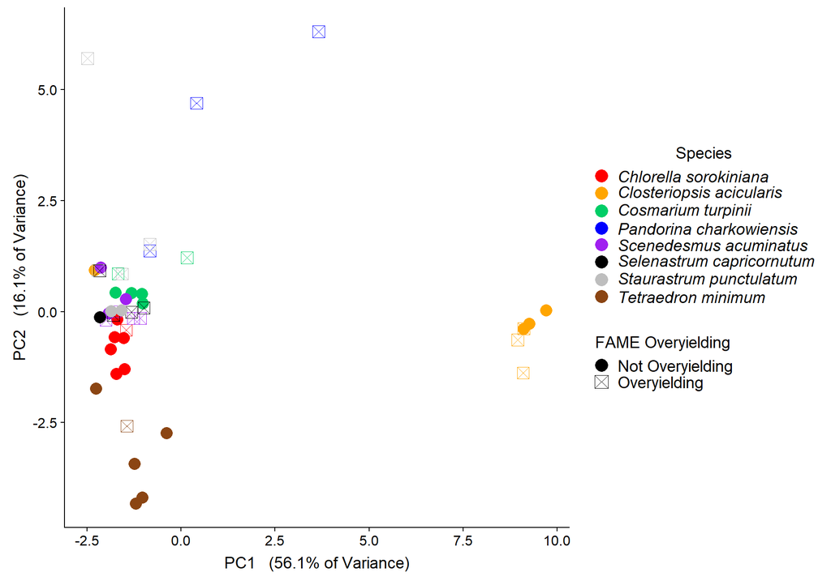

```r
my_expression<-expression(paste(italic("Chlorella sorokiniana")))
my_expression1<-expression(paste(italic("Closteriopsis acicularis")))
my_expression2<-expression(paste(italic("Cosmarium turpinii")))
my_expression3<-expression(paste(italic("Pandorina charkowiensis")))
my_expression4<-expression(paste(italic("Scenedesmus acuminatus")))
my_expression5<-expression(paste(italic("Selenastrum capricornutum")))
my_expression6<-expression(paste(italic("Staurastrum punctulatum")))
my_expression7<-expression(paste(italic("Tetraedron minimum")))
data<-cbind(new.pca$x,Aggregated.Go.Tables[,30:32],Aggregated.Go.Tables[,1])
data$Species<-as.factor(data$Species)

Figure.S2<-ggplot(data, aes(PC1,PC2,colour=data$Species,shape=data$FAME.Overyielding,size=3))+
  geom_point()+
  theme(legend.text.align = 0,legend.title.align=0.5,legend.key=element_rect(fill=NA),panel.grid.major = element_blank(), panel.grid.minor = element_blank(),panel.background = element_blank(), axis.line = element_line(colour = "black"),axis.text=element_text(size = 12),axis.title=element_text(size=14,face="plain"),legend.title=element_text(size=14),legend.text=element_text(size=14))+
  guides(color=guide_legend(override.aes=list(size=5)),shape=guide_legend(override.aes=list(size=5)))+
  scale_shape_manual("FAME Overyielding",labels=c("Not Overyielding", "Overyielding"),values=c(16,7))+
  scale_colour_manual("Species",labels=c(my_expression,my_expression1,my_expression2,my_expression3,my_expression4,my_expression5,my_expression6,my_expression7),values=c("red","orange","springgreen3","blue","purple","black","gray","chocolate4"))+
  scale_size(guide="none")+
  xlab("PC1   (56.1% of Variance)")+
  ylab ("PC2   (16.1% of Variance)")
Figure.S2
```

Section 4: Shifts in expression at the gene-level caused by the diversity treatment significantly predict shifts in metrics of biomass quality for bio-oil, including FAME, Cetane Number, and Higher Heating Value

Figure S3 Across multiple species of algae, we found that the relative change in gene expression between monoculture and biculture growing conditions significantly predicts the relative change between the monoculture and biculture levels of Cetane Number, which was measured from the extracted fatty acid methyl esters. Correlation between log2 fold change of gene expression and Cetane Number in biculture relative to monoculture were evaluated via simple linear regression models with FDR significance corrections. Orthologs in Chlorella variabilis are used for gene annotation when possible. Occasionally, we note orthologs from other model organisms from which we needed to infer gene annotation.

Figure S4 Across multiple species of algae, we found that the relative change in gene expression between monoculture and biculture growing conditions significantly predicts the relative change between the monoculture and biculture levels of Higher Heating Value, which was measured from the extracted fatty acid methyl esters. Correlation between log2 fold change of gene expression and Higher Heating Value in biculture relative to monoculture were evaluated via simple linear regression models with FDR significance corrections. Orthologs in Chlorella variabilis are used for gene annotation when possible. Occasionally, we note orthologs from other model organisms from which we needed to infer gene annotation.

```r
rm(list = ls())
library(gridExtra)
library(ggplot2)
library(grid)
library(cowplot)

my_expression1<-expression(paste(italic("Chlorella sorokiniana")))
my_expression2<-expression(paste(italic("Closteriopsis acicularis")))
my_expression3<-expression(paste(italic("Cosmarium turpinii")))
my_expression4<-expression(paste(italic("Pandorina charkowiensis")))
my_expression5<-expression(paste(italic("Scenedesmus acuminatus")))
my_expression6<-expression(paste(italic("Selenastrum capricornutum")))
my_expression7<-expression(paste(italic("Staurastrum punctulatum")))
my_expression8<-expression(paste(italic("Tetraedron minimum")))

XP_005850941.1<-read.csv("C:\\Users\\Sara\\Desktop\\Differential Expression by Basti\\CetaneNumber_XP_005850941.1.csv")
XP_005850676.1<-read.csv("C:\\Users\\Sara\\Desktop\\Differential Expression by Basti\\CetaneNumber_XP_005850676.1.csv")
XP_005851543.1<-read.csv("C:\\Users\\Sara\\Desktop\\Differential Expression by Basti\\CetaneNumber_XP_005851543.1.csv")
XP_005843528.1<-read.csv("C:\\Users\\Sara\\Desktop\\Differential Expression by Basti\\CetaneNumber_XP_005843528.1.csv")

summary(lm(logFC~log2FCofCN,data=XP_005850941.1))
```

```
##
## Call:
## lm(formula = logFC ~ log2FCofCN, data = XP_005850941.1)
##
## Residuals:
##     Min      1Q  Median      3Q     Max
## -3.4452 -0.9422  0.0435  0.9293  2.6531
##
## Coefficients:
##             Estimate Std. Error t value Pr(>|t|)
## (Intercept)   0.2724     0.2098   1.298    0.201
## log2FCofCN    4.5940     0.9639   4.766 1.99e-05 ***
## ---
## Signif. codes:  0 '***' 0.001 '**' 0.01 '*' 0.05 '.' 0.1 ' ' 1
##
## Residual standard error: 1.322 on 45 degrees of freedom
## Multiple R-squared:  0.3355, Adjusted R-squared:  0.3207
## F-statistic: 22.72 on 1 and 45 DF,  p-value: 1.995e-05
```

```r
my_grob = grobTree(textGrob(bquote(Adjusted~R^2 == .(paste(round(0.320706173, 2)))), x=0.03,  y=0.9, hjust=0, gp=gpar(col="black", fontsize=12, fontface="italic")))
XP_005850941.1.plot<-ggplot(XP_005850941.1,aes(logFC,log2FCofCN))+
  geom_point(aes(colour=factor(Species),size=3)) +
  geom_smooth(method=lm,colour='black',fullrange=TRUE)+
  theme(legend.text.align = 0,legend.key=element_rect(fill=NA),panel.grid.major = element_blank(), panel.grid.minor = element_blank(),panel.background = element_blank(), axis.line = element_line(colour = "black"),axis.text=element_text(size = 12),axis.title=element_text(size=14,face="plain"),legend.title=element_text(size=12),legend.text=element_text(size=12))+
  xlab("Log2FC of E1Z5Y8_CHLVA \n Fatty acid desaturase \n GO: Fatty Acid Biosynthetic Process")+
  ylab("Cetane Number  \n (Log2FC)")+
  annotation_custom(my_grob)+
  scale_colour_manual(guide="none","Algal Species",labels=c(my_expression1,my_expression2,my_expression3,my_expression4,my_expression5,my_expression6,my_expression7,my_expression8),values=c("red","orange","springgreen3","blue","purple","black","gray","chocolate4"))+
  scale_size(guide="none")+
  scale_x_continuous(expand=c(0,0),limits=c(-5,5)) +
  scale_y_continuous(expand=c(0,0),limits=c(-5,5)) +
  coord_cartesian(xlim=c(-3.0,3.0), ylim=c(-.6,0.6))

summary(lm(logFC~log2FCofCN,data=XP_005850676.1))
```

```
##
## Call:
## lm(formula = logFC ~ log2FCofCN, data = XP_005850676.1)
##
## Residuals:
##     Min      1Q  Median      3Q     Max
## -1.5922 -0.2848  0.0416  0.4105  1.0865
##
## Coefficients:
##             Estimate Std. Error t value Pr(>|t|)
## (Intercept)   0.1386     0.1013   1.368 0.179294
## log2FCofCN   -2.6190     0.6089  -4.301 0.000114 ***
## ---
## Signif. codes:  0 '***' 0.001 '**' 0.01 '*' 0.05 '.' 0.1 ' ' 1
##
## Residual standard error: 0.627 on 38 degrees of freedom
## Multiple R-squared:  0.3274, Adjusted R-squared:  0.3097
## F-statistic:  18.5 on 1 and 38 DF,  p-value: 0.0001145
```

```r
my_grob = grobTree(textGrob(bquote(Adjusted~R^2 == .(paste(round(0.309726784, 2)))), x=0.65,  y=0.9, hjust=0, gp=gpar(col="black", fontsize=12, fontface="italic")))
XP_005850676.1.plot<-ggplot(XP_005850676.1,aes(logFC,log2FCofCN))+
  geom_point(aes(colour=factor(Species),size=3)) +
  geom_smooth(method=lm,colour='black',fullrange=TRUE)+
  theme(legend.text.align = 0,legend.key=element_rect(fill=NA),panel.grid.major = element_blank(), panel.grid.minor = element_blank(),panel.background = element_blank(), axis.line = element_line(colour = "black"),axis.text=element_text(size = 12),axis.title=element_text(size=14,face="plain"),legend.title=element_text(size=12),legend.text=element_text(size=12))+
  xlab("Log2FC of E1Z629_CHLVA \n Dihydrolipoamide succinyltransferase \n GO: Dihydrolipoyllysine-residue Succinyltransferase Activity")+
  ylab("Cetane Number \n (Log2FC)")+
  annotation_custom(my_grob)+
  scale_colour_manual(guide="none","Algal Species",labels=c(my_expression1,my_expression2,my_expression3,my_expression4,my_expression6,my_expression7,my_expression8),values=c("red","orange","springgreen3","blue","black","gray","chocolate4"))+
  scale_size(guide="none")+
  scale_x_continuous(expand=c(0,0),limits=c(-5,5)) +
  scale_y_continuous(expand=c(0,0),limits=c(-5,5)) +
  coord_cartesian(xlim=c(-2.0,2), ylim=c(-.4,0.4))

summary(lm(logFC~log2FCofCN,data=XP_005851543.1))
```

```
##
## Call:
## lm(formula = logFC ~ log2FCofCN, data = XP_005851543.1)
##
## Residuals:
##      Min       1Q   Median       3Q      Max
## -0.31552 -0.11490 -0.02804  0.14281  0.32540
##
## Coefficients:
##             Estimate Std. Error t value Pr(>|t|)
## (Intercept)  0.35924    0.07921   4.535 0.001083 **
## log2FCofCN   1.47590    0.25370   5.817 0.000169 ***
## ---
## Signif. codes:  0 '***' 0.001 '**' 0.01 '*' 0.05 '.' 0.1 ' ' 1
##
## Residual standard error: 0.2207 on 10 degrees of freedom
## Multiple R-squared:  0.7719, Adjusted R-squared:  0.7491
## F-statistic: 33.84 on 1 and 10 DF,  p-value: 0.0001689
```

```r
my_grob = grobTree(textGrob(bquote(Adjusted~R^2 == .(paste(round(0.749101941, 2)))), x=0.03,  y=0.9, hjust=0, gp=gpar(col="black", fontsize=12, fontface="italic")))
XP_005851543.1.plot<-ggplot(XP_005851543.1,aes(logFC,log2FCofCN))+
  geom_point(aes(colour=factor(Species),size=3)) +
  geom_smooth(method=lm,colour='black',fullrange=TRUE)+
  theme(legend.text.align = 0,legend.key=element_rect(fill=NA),panel.grid.major = element_blank(), panel.grid.minor = element_blank(),panel.background = element_blank(), axis.line = element_line(colour = "black"),axis.text=element_text(size = 12),axis.title=element_text(size=14,face="plain"),legend.title=element_text(size=12),legend.text=element_text(size=12))+
  xlab("Log2FC of E1Z510_CHLVA (A8J143_CHLRE) \n Lipid-droplet associated hydrolase \n GO: Lipid Storage")+
  ylab("Cetane Number \n (Log2FC)")+
  annotation_custom(my_grob)+
  scale_colour_manual(guide="none","Algal Species",labels=c(my_expression5,my_expression6),values=c("purple","black"))+
  scale_size(guide="none")+
  scale_x_continuous(expand=c(0,0),limits=c(-15,15)) +
  scale_y_continuous(expand=c(0,0),limits=c(-15,15)) +
  coord_cartesian(xlim=c(-1,1), ylim=c(-.6,0.5))

summary(lm(logFC~log2FCofCN,data=XP_005843528.1))
```

```
##
## Call:
## lm(formula = logFC ~ log2FCofCN, data = XP_005843528.1)
##
## Residuals:
##     Min      1Q  Median      3Q     Max
## -4.1940 -1.8046  0.0952  1.6781  3.9842
##
## Coefficients:
##             Estimate Std. Error t value Pr(>|t|)
## (Intercept)  -0.3613     0.6031  -0.599 0.557556
## log2FCofCN   11.0663     2.2991   4.813 0.000191 ***
## ---
## Signif. codes:  0 '***' 0.001 '**' 0.01 '*' 0.05 '.' 0.1 ' ' 1
##
## Residual standard error: 2.319 on 16 degrees of freedom
## Multiple R-squared:  0.5915, Adjusted R-squared:  0.566
## F-statistic: 23.17 on 1 and 16 DF,  p-value: 0.0001911
```

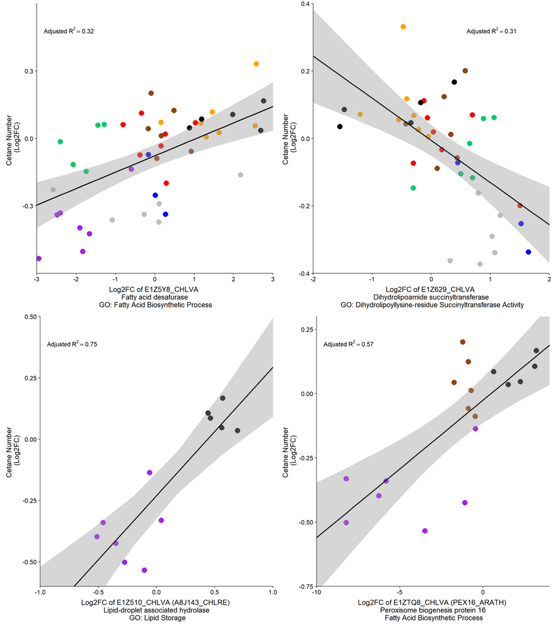

```r
my_grob = grobTree(textGrob(bquote(Adjusted~R^2 == .(paste(round(0.565962001, 2)))), x=0.03,  y=0.90, hjust=0, gp=gpar(col="black", fontsize=12, fontface="italic")))
XP_005843528.1.plot<-ggplot(XP_005843528.1,aes(logFC,log2FCofCN))+
  geom_point(aes(colour=factor(Species),size=3)) +
  geom_smooth(method=lm,colour='black',fullrange=TRUE)+
  theme(legend.text.align = 0,legend.key=element_rect(fill=NA),panel.grid.major = element_blank(), panel.grid.minor = element_blank(),panel.background = element_blank(), axis.line = element_line(colour = "black"),axis.text=element_text(size = 12),axis.title=element_text(size=14,face="plain"),legend.title=element_text(size=12),legend.text=element_text(size=12))+
  xlab("Log2FC of E1ZTQ8_CHLVA (PEX16_ARATH) \n Peroxisome biogenesis protein 16 \n Fatty Acid Biosynthetic Process")+
  ylab("Cetane Number \n (Log2FC)")+
  annotation_custom(my_grob)+
  scale_colour_manual(guide="none","Algal Species",labels=c(my_expression5,my_expression6,my_expression8),values=c("purple","black","chocolate4"))+
  scale_size(guide="none")+
  scale_x_continuous(expand=c(0,0),limits=c(-15,15)) +
  scale_y_continuous(expand=c(0,0),limits=c(-15,15)) +
  coord_cartesian(xlim=c(-10,4), ylim=c(-.75,0.3))

Figure.S3<-plot_grid(XP_005850941.1.plot,XP_005850676.1.plot,XP_005851543.1.plot,XP_005843528.1.plot,ncol = 2)
Figure.S3
```

```r
my_expression1<-expression(paste(italic("Chlorella sorokiniana")))
my_expression2<-expression(paste(italic("Closteriopsis acicularis")))
my_expression3<-expression(paste(italic("Cosmarium turpinii")))
my_expression4<-expression(paste(italic("Pandorina charkowiensis")))
my_expression5<-expression(paste(italic("Scenedesmus acuminatus")))
my_expression6<-expression(paste(italic("Selenastrum capricornutum")))
my_expression7<-expression(paste(italic("Staurastrum punctulatum")))
my_expression8<-expression(paste(italic("Tetraedron minimum")))

XP_005843528.1<-read.csv("C:\\Users\\Sara\\Desktop\\Differential Expression by Basti\\HHV_XP_005843528.1.csv")
XP_005851543.1<-read.csv("C:\\Users\\Sara\\Desktop\\Differential Expression by Basti\\HHV_XP_005851543.1.csv")
XP_005850941.1<-read.csv("C:\\Users\\Sara\\Desktop\\Differential Expression by Basti\\HHV_XP_005850941.1.csv")
XP_005847908.1<-read.csv("C:\\Users\\Sara\\Desktop\\Differential Expression by Basti\\HHV_XP_005847908.1.csv")
XP_005849398.1<-read.csv("C:\\Users\\Sara\\Desktop\\Differential Expression by Basti\\HHV_XP_005849398.1.csv")

summary(lm(logFC~log2FCofHHV,data=XP_005843528.1))
```

```
##
## Call:
## lm(formula = logFC ~ log2FCofHHV, data = XP_005843528.1)
##
## Residuals:
##     Min      1Q  Median      3Q     Max
## -3.8413 -0.8336 -0.2973  0.7946  4.2274
##
## Coefficients:
##             Estimate Std. Error t value Pr(>|t|)
## (Intercept)   1.0080     0.6087   1.656    0.117
## log2FCofHHV 577.5902    90.3399   6.394  8.9e-06 ***
## ---
## Signif. codes:  0 '***' 0.001 '**' 0.01 '*' 0.05 '.' 0.1 ' ' 1
##
## Residual standard error: 1.925 on 16 degrees of freedom
## Multiple R-squared:  0.7187, Adjusted R-squared:  0.7011
## F-statistic: 40.88 on 1 and 16 DF,  p-value: 8.897e-06
```

```r
my_grob = grobTree(textGrob(bquote(Adjusted~R^2 == .(paste(round(0.701110228, 3)))), x=0.03,  y=0.93, hjust=0, gp=gpar(col="black", fontsize=12, fontface="italic")))
XP_005843528.1.plot<-ggplot(XP_005843528.1,aes(logFC,log2FCofHHV))+
  geom_point(aes(colour=factor(Species),size=3)) +
  geom_smooth(method=lm,colour='black',fullrange=TRUE)+
  theme(legend.text.align = 0,legend.key=element_rect(fill=NA),panel.grid.major = element_blank(), panel.grid.minor = element_blank(),panel.background = element_blank(), axis.line = element_line(colour = "black"),axis.text=element_text(size = 12),axis.title=element_text(size=14,face="plain"),legend.title=element_text(size=12),legend.text=element_text(size=12))+
  xlab("Log2FC of E1ZS17_CHLVA \n Very-long-chain 3-ketoacyl-CoA synthase \n GO: Fatty Acid Biosynthetic Process ")+
  ylab("Higher Heating Value\n (Log2FC)")+
  annotation_custom(my_grob)+
  scale_colour_manual(guide="none","Algal Species",labels=c(my_expression5,my_expression6,my_expression8),values=c("purple","black","chocolate4"))+
  scale_size(guide="none")+
  scale_x_continuous(expand=c(0,0),limits=c(-15,15)) +
  scale_y_continuous(expand=c(0,0),limits=c(-15,15)) +
  coord_cartesian(xlim=c(-9,3.5), ylim=c(-.015,0.005))

summary(lm(logFC~log2FCofHHV,data=XP_005851543.1))
```

```
##
## Call:
## lm(formula = logFC ~ log2FCofHHV, data = XP_005851543.1)
##
## Residuals:
##      Min       1Q   Median       3Q      Max
## -0.27157 -0.11567 -0.01704  0.11444  0.29666
##
## Coefficients:
##             Estimate Std. Error t value Pr(>|t|)
## (Intercept)  0.45660    0.07862   5.808 0.000171 ***
## log2FCofHHV 65.92747    9.72777   6.777 4.88e-05 ***
## ---
## Signif. codes:  0 '***' 0.001 '**' 0.01 '*' 0.05 '.' 0.1 ' ' 1
##
## Residual standard error: 0.1954 on 10 degrees of freedom
## Multiple R-squared:  0.8212, Adjusted R-squared:  0.8033
## F-statistic: 45.93 on 1 and 10 DF,  p-value: 4.875e-05
```

```r
my_grob = grobTree(textGrob(bquote(Adjusted~R^2 == .(paste(round(0.803329379, 3)))), x=0.03,  y=0.93, hjust=0, gp=gpar(col="black", fontsize=12, fontface="italic")))
XP_005851543.1.plot<-ggplot(XP_005851543.1,aes(logFC,log2FCofHHV))+
  geom_point(aes(colour=factor(Species),size=3)) +
  geom_smooth(method=lm,colour='black',fullrange=TRUE)+
  theme(legend.text.align = 0,legend.key=element_rect(fill=NA),panel.grid.major = element_blank(), panel.grid.minor = element_blank(),panel.background = element_blank(), axis.line = element_line(colour = "black"),axis.text=element_text(size = 12),axis.title=element_text(size=14,face="plain"),legend.title=element_text(size=12),legend.text=element_text(size=12))+
  xlab("Log2FC of E1Z510_CHLVA (A8J143_CHLRE) \n Lipid-droplet associated hydrolase \n GO: Lipid Storage ")+
  ylab("Higher Heating Value\n  (Log2FC)")+
  annotation_custom(my_grob)+
  scale_colour_manual(guide="none","Algal Species",labels=c(my_expression5,my_expression6),values=c("purple","black"))+
  scale_size(guide="none")+
  scale_x_continuous(expand=c(0,0),limits=c(-15,15)) +
  scale_y_continuous(expand=c(0,0),limits=c(-15,15)) +
  coord_cartesian(xlim=c(-0.6,0.9), ylim=c(-0.015,0.0055))

summary(lm(logFC~log2FCofHHV,data=XP_005850941.1))
```

```
##
## Call:
## lm(formula = logFC ~ log2FCofHHV, data = XP_005850941.1)
##
## Residuals:
##     Min      1Q  Median      3Q     Max
## -4.2057 -0.6166  0.2561  0.8423  2.3548
##
## Coefficients:
##             Estimate Std. Error t value Pr(>|t|)
## (Intercept)   0.3447     0.2244   1.536    0.132
## log2FCofHHV 212.8381    48.3429   4.403 6.52e-05 ***
## ---
## Signif. codes:  0 '***' 0.001 '**' 0.01 '*' 0.05 '.' 0.1 ' ' 1
##
## Residual standard error: 1.355 on 45 degrees of freedom
## Multiple R-squared:  0.3011, Adjusted R-squared:  0.2855
## F-statistic: 19.38 on 1 and 45 DF,  p-value: 6.517e-05
```

```r
my_grob = grobTree(textGrob(bquote(Adjusted~R^2 == .(paste(round(0.285532014, 2)))), x=0.03,  y=0.93, hjust=0, gp=gpar(col="black", fontsize=12, fontface="italic")))
XP_005850941.1.plot<-ggplot(XP_005850941.1,aes(logFC,log2FCofHHV))+
  geom_point(aes(colour=factor(Species),size=3)) +
  geom_smooth(method=lm,colour='black',fullrange=TRUE)+
  theme(legend.text.align = 0,legend.key=element_rect(fill=NA),panel.grid.major = element_blank(), panel.grid.minor = element_blank(),panel.background = element_blank(), axis.line = element_line(colour = "black"),axis.text=element_text(size = 12),axis.title=element_text(size=14,face="plain"),legend.title=element_text(size=12),legend.text=element_text(size=12))+
  xlab("Log2FC of E1Z5Y8_CHLVA \n Fatty acid desaturase \n GO: Fatty Acid Biosynthetic Process")+
  ylab("Higher Heating Value\n  (Log2FC)")+
  annotation_custom(my_grob)+
  scale_colour_manual(guide="none","Algal Species",labels=c(my_expression1,my_expression2,my_expression3,my_expression4,my_expression5,my_expression6,my_expression7,my_expression8),values=c("red","orange","springgreen3","blue","purple","black","gray","chocolate4"))+
  scale_size(guide="none")+
  scale_x_continuous(expand=c(0,0),limits=c(-15,15)) +
  scale_y_continuous(expand=c(0,0),limits=c(-15,15)) +
  coord_cartesian(xlim=c(-4.0,3.0), ylim=c(-0.015,0.0055))

summary(lm(logFC~log2FCofHHV,data=XP_005847908.1))
```

```
##
## Call:
## lm(formula = logFC ~ log2FCofHHV, data = XP_005847908.1)
##
## Residuals:
##      Min       1Q   Median       3Q      Max
## -0.47813 -0.08954  0.01641  0.13422  0.27974
##
## Coefficients:
##             Estimate Std. Error t value Pr(>|t|)
## (Intercept)  -0.2346     0.1025  -2.288 0.042942 *
## log2FCofHHV -71.3851    12.9633  -5.507 0.000184 ***
## ---
## Signif. codes:  0 '***' 0.001 '**' 0.01 '*' 0.05 '.' 0.1 ' ' 1
##
## Residual standard error: 0.211 on 11 degrees of freedom
## Multiple R-squared:  0.7338, Adjusted R-squared:  0.7096
## F-statistic: 30.32 on 1 and 11 DF,  p-value: 0.0001844
```

```r
my_grob = grobTree(textGrob(bquote(Adjusted~R^2 == .(paste(round(0.709610374, 3)))), x=0.75,  y=0.93, hjust=0, gp=gpar(col="black", fontsize=12, fontface="italic")))
XP_005847908.1.plot<-ggplot(XP_005847908.1,aes(logFC,log2FCofHHV))+
  geom_point(aes(colour=factor(Species),size=3)) +
  geom_smooth(method=lm,colour='black',fullrange=TRUE)+
  theme(legend.text.align = 0,legend.key=element_rect(fill=NA),panel.grid.major = element_blank(), panel.grid.minor = element_blank(),panel.background = element_blank(), axis.line = element_line(colour = "black"),axis.text=element_text(size = 12),axis.title=element_text(size=14,face="plain"),legend.title=element_text(size=12),legend.text=element_text(size=12))+
  xlab("Log2FC of E1ZE47_CHLVA (A8J9C6_CHLRE) \n UDP-3-O-acyl N-acetylglucosamine deacetylase \n GO: Lipid A Biosynthetic Process")+
  ylab("Higher Heating Value\n  (Log2FC)")+
  annotation_custom(my_grob)+
  scale_colour_manual(guide="none","Algal Species",labels=c(my_expression5,my_expression8),values=c("purple","chocolate4"))+
  scale_size(guide="none")+
  scale_x_continuous(expand=c(0,0),limits=c(-15,15)) +
  scale_y_continuous(expand=c(0,0),limits=c(-15,15)) +
  coord_cartesian(xlim=c(-0.75,1.1), ylim=c(-0.015,0.0055))

summary(lm(logFC~log2FCofHHV,data=XP_005849398.1))
```

```
##
## Call:
## lm(formula = logFC ~ log2FCofHHV, data = XP_005849398.1)
##
## Residuals:
##      Min       1Q   Median       3Q      Max
## -1.17154 -0.25871 -0.01043  0.28264  0.84094
##
## Coefficients:
##              Estimate Std. Error t value Pr(>|t|)
## (Intercept)  -0.23757    0.07215  -3.293 0.001936 **
## log2FCofHHV -62.99715   15.54297  -4.053 0.000198 ***
## ---
## Signif. codes:  0 '***' 0.001 '**' 0.01 '*' 0.05 '.' 0.1 ' ' 1
##
## Residual standard error: 0.4358 on 45 degrees of freedom
## Multiple R-squared:  0.2674, Adjusted R-squared:  0.2512
## F-statistic: 16.43 on 1 and 45 DF,  p-value: 0.0001977
```

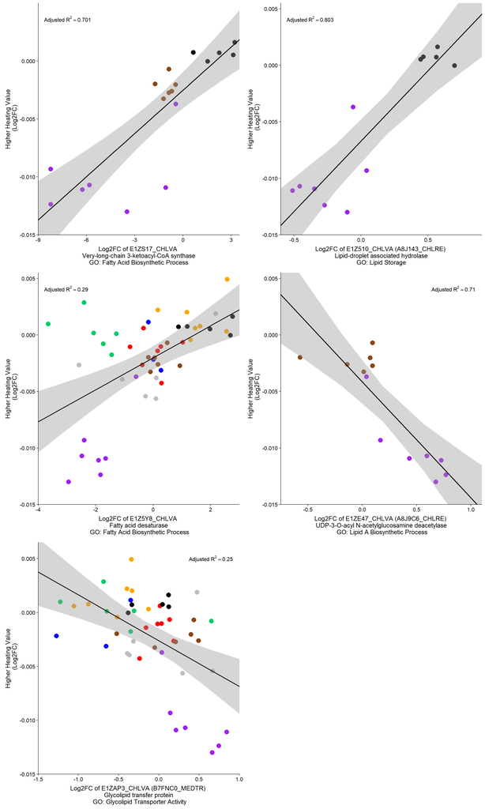

```r
my_grob = grobTree(textGrob(bquote(Adjusted~R^2 == .(paste(round(0.251150729, 2)))), x=0.75,  y=0.93, hjust=0, gp=gpar(col="black", fontsize=12, fontface="italic")))
XP_005849398.1.plot<-ggplot(XP_005849398.1,aes(logFC,log2FCofHHV))+
  geom_point(aes(colour=factor(Species),size=3)) +
  geom_smooth(method=lm,colour='black',fullrange=TRUE)+
  theme(legend.text.align = 0,legend.key=element_rect(fill=NA),panel.grid.major = element_blank(), panel.grid.minor = element_blank(),panel.background = element_blank(), axis.line = element_line(colour = "black"),axis.text=element_text(size = 12),axis.title=element_text(size=14,face="plain"),legend.title=element_text(size=12),legend.text=element_text(size=12))+
  xlab("Log2FC of E1ZAP3_CHLVA (B7FNC0_MEDTR) \n Glycolipid transfer protein \n GO: Glycolipid Transporter Activity")+
  ylab("Higher Heating Value\n  (Log2FC)")+
  annotation_custom(my_grob)+
  scale_colour_manual(guide="none","Algal Species",labels=c(my_expression1,my_expression2,my_expression3,my_expression4,my_expression5,my_expression6,my_expression7,my_expression8),values=c("red","orange","springgreen3","blue","purple","black","gray","chocolate4"))+
  scale_size(guide="none")+
  scale_x_continuous(expand=c(0,0),limits=c(-15,15)) +
  scale_y_continuous(expand=c(0,0),limits=c(-15,15)) +
  coord_cartesian(xlim=c(-1.5,1), ylim=c(-0.015,0.0065))

Figure.S4<-plot_grid(XP_005843528.1.plot,XP_005851543.1.plot,XP_005850941.1.plot,XP_005847908.1.plot,XP_005849398.1.plot,ncol = 2)
Figure.S4
```

Section 5: Background experiments used for species and media selection, as well as growth curves for all treatments in the main experiment.

Figure S5 Growth curves of all monocultures and bicultures using Chlorophyll-a fluorescence. Dashed vertical line at Day 48 indicates when algal biomass was collected for RNA sequencing. Color indicates replicate.

```r
data<-read.csv("C:/Users/Sara/Desktop/DIMENSIONS biofuel suppl/growth curves.csv")
levels(data$Trmt)
```

```
##  [1] "S1"    "S1.S2" "S1.S3" "S1.S4" "S1.S5" "S1.S6" "S1.S7" "S1.S8"
##  [9] "S2"    "S2.S3" "S2.S4" "S2.S5" "S2.S6" "S2.S7" "S2.S8" "S3"
## [17] "S3.S4" "S3.S5" "S3.S6" "S3.S7" "S3.S8" "S4"    "S4.S5" "S4.S6"
## [25] "S4.S7" "S4.S8" "S5"    "S5.S6" "S5.S7" "S5.S8" "S6"    "S6.S7"
## [33] "S6.S8" "S7"    "S7.S8" "S8"
```

```r
data<-data[!is.na(data$F),]
data$Rep<-as.factor(data$Rep)

Trmt.S1.M<-data[(data$Trmt=="S1"),]
Trmt.S2.M<-data[(data$Trmt=="S2"),]
Trmt.S3.M<-data[(data$Trmt=="S3"),]
Trmt.S4.M<-data[(data$Trmt=="S4"),]
Trmt.S5.M<-data[(data$Trmt=="S5"),]
Trmt.S6.M<-data[(data$Trmt=="S6"),]
Trmt.S7.M<-data[(data$Trmt=="S7"),]
Trmt.S8.M<-data[(data$Trmt=="S8"),]
Trmt.S1.S2<-data[(data$Trmt=="S1.S2"),]
Trmt.S1.S3<-data[(data$Trmt=="S1.S3"),]
Trmt.S1.S4<-data[(data$Trmt=="S1.S4"),]
Trmt.S1.S5<-data[(data$Trmt=="S1.S5"),]
Trmt.S1.S6<-data[(data$Trmt=="S1.S6"),]
Trmt.S1.S7<-data[(data$Trmt=="S1.S7"),]
Trmt.S1.S8<-data[(data$Trmt=="S1.S8"),]
Trmt.S2.S3<-data[(data$Trmt=="S2.S3"),]
Trmt.S2.S4<-data[(data$Trmt=="S2.S4"),]
Trmt.S2.S5<-data[(data$Trmt=="S2.S5"),]
Trmt.S2.S6<-data[(data$Trmt=="S2.S6"),]
Trmt.S2.S7<-data[(data$Trmt=="S2.S7"),]
Trmt.S2.S8<-data[(data$Trmt=="S2.S8"),]
Trmt.S3.S4<-data[(data$Trmt=="S3.S4"),]
Trmt.S3.S5<-data[(data$Trmt=="S3.S5"),]
Trmt.S3.S6<-data[(data$Trmt=="S3.S6"),]
Trmt.S3.S7<-data[(data$Trmt=="S3.S7"),]
Trmt.S3.S8<-data[(data$Trmt=="S3.S8"),]
Trmt.S4.S5<-data[(data$Trmt=="S4.S5"),]
Trmt.S4.S6<-data[(data$Trmt=="S4.S6"),]
Trmt.S4.S7<-data[(data$Trmt=="S4.S7"),]
Trmt.S4.S8<-data[(data$Trmt=="S4.S8"),]
Trmt.S5.S6<-data[(data$Trmt=="S5.S6"),]
Trmt.S5.S7<-data[(data$Trmt=="S5.S7"),]
Trmt.S5.S8<-data[(data$Trmt=="S5.S8"),]
Trmt.S6.S7<-data[(data$Trmt=="S6.S7"),]
Trmt.S6.S8<-data[(data$Trmt=="S6.S8"),]
Trmt.S7.S8<-data[(data$Trmt=="S7.S8"),]

Monocultures<-rbind(Trmt.S1.M,Trmt.S2.M,Trmt.S3.M,Trmt.S4.M,Trmt.S5.M,Trmt.S6.M,Trmt.S8.M,Trmt.S8.M )

S1.M.Figure<-ggplot(Trmt.S1.M,aes(x=Day,y=F,colour=Rep))+
  geom_point(alpha=0.5, size = 2)+
  scale_y_log10()+
  xlab("Day")+
  ylab("Fluorescence")+
  xlim(c(0,55))+
  theme(plot.title = element_text(hjust = 0.5),legend.text.align = 0,legend.key=element_rect(fill=NA),panel.grid.major = element_blank(), panel.grid.minor = element_blank(),panel.background = element_blank(), axis.line = element_line(colour = "black"),axis.text=element_text(size = 16),axis.title=element_text(size=18,face="plain"),legend.title=element_text(size=16),legend.text=element_text(size=16))+
  scale_color_manual(guide=FALSE,values=c("black","blue","#D55E00"))+
  geom_vline(xintercept=48,linetype='dashed')+
  ggtitle("Chlorella")

S2.M.Figure<-ggplot(Trmt.S2.M,aes(x=Day,y=F,colour=Rep))+
  geom_point(alpha=0.5, size = 2)+
  scale_y_log10()+
  xlab("Day")+
  ylab("")+
  xlim(c(0,55))+
  theme(plot.title = element_text(hjust = 0.5),legend.text.align = 0,legend.key=element_rect(fill=NA),panel.grid.major = element_blank(), panel.grid.minor = element_blank(),panel.background = element_blank(), axis.line = element_line(colour = "black"),axis.text=element_text(size = 16),axis.title=element_text(size=18,face="plain"),legend.title=element_text(size=16),legend.text=element_text(size=16))+
  scale_color_manual(guide=FALSE,values=c("black","blue","#D55E00"))+
  geom_vline(xintercept=48,linetype='dashed')+
  ggtitle("Closteriopsis")

S3.M.Figure<-ggplot(Trmt.S3.M,aes(x=Day,y=F,colour=Rep))+
  geom_point(alpha=0.5, size = 2)+
  scale_y_log10()+
  xlab("Day")+
  ylab("")+
  xlim(c(0,55))+
  theme(plot.title = element_text(hjust = 0.5),legend.text.align = 0,legend.key=element_rect(fill=NA),panel.grid.major = element_blank(), panel.grid.minor = element_blank(),panel.background = element_blank(), axis.line = element_line(colour = "black"),axis.text=element_text(size = 16),axis.title=element_text(size=18,face="plain"),legend.title=element_text(size=16),legend.text=element_text(size=16))+
  scale_color_manual(guide=FALSE,values=c("black","blue","#D55E00"))+
  geom_vline(xintercept=48,linetype='dashed')+
  ggtitle("Cosmarium")

S4.M.Figure<-ggplot(Trmt.S4.M,aes(x=Day,y=F,colour=Rep))+
  geom_point(alpha=0.5, size = 2)+
  scale_y_log10()+
  xlab("Day")+
  ylab("Fluorescence")+
  theme(plot.title = element_text(hjust = 0.5),legend.text.align = 0,legend.key=element_rect(fill=NA),panel.grid.major = element_blank(), panel.grid.minor = element_blank(),panel.background = element_blank(), axis.line = element_line(colour = "black"),axis.text=element_text(size = 16),axis.title=element_text(size=18,face="plain"),legend.title=element_text(size=16),legend.text=element_text(size=16))+
  scale_color_manual(guide=FALSE,values=c("black","blue","#D55E00"))+
  geom_vline(xintercept=48,linetype='dashed')+
  ggtitle("Pandorina")

S5.M.Figure<-ggplot(Trmt.S5.M,aes(x=Day,y=F,colour=Rep))+
  geom_point(alpha=0.5, size = 2)+
  scale_y_log10()+
  xlab("Day")+
  ylab("")+
  xlim(c(0,55))+
  theme(plot.title = element_text(hjust = 0.5),legend.text.align = 0,legend.key=element_rect(fill=NA),panel.grid.major = element_blank(), panel.grid.minor = element_blank(),panel.background = element_blank(), axis.line = element_line(colour = "black"),axis.text=element_text(size = 16),axis.title=element_text(size=18,face="plain"),legend.title=element_text(size=16),legend.text=element_text(size=16))+
  scale_color_manual(guide=FALSE,values=c("black","blue","#D55E00"))+
  geom_vline(xintercept=48,linetype='dashed')+
  ggtitle("Scenedesmus")

S6.M.Figure<-ggplot(Trmt.S6.M,aes(x=Day,y=F,colour=Rep))+
  geom_point(alpha=0.5, size = 2)+
  scale_y_log10()+
  xlab("Day")+
  ylab("")+
  xlim(c(0,55))+
  theme(plot.title = element_text(hjust = 0.5),legend.text.align = 0,legend.key=element_rect(fill=NA),panel.grid.major = element_blank(), panel.grid.minor = element_blank(),panel.background = element_blank(), axis.line = element_line(colour = "black"),axis.text=element_text(size = 16),axis.title=element_text(size=18,face="plain"),legend.title=element_text(size=16),legend.text=element_text(size=16))+
  scale_color_manual(guide=FALSE,values=c("black","blue","#D55E00"))+
  geom_vline(xintercept=48,linetype='dashed')+
  ggtitle("Selenastrum")

S7.M.Figure<-ggplot(Trmt.S7.M,aes(x=Day,y=F,colour=Rep))+
  geom_point(alpha=0.5, size = 2)+
  scale_y_log10()+
  xlab("Day")+
  xlim(c(0,55))+
  ylab("Fluorescence")+
  theme(plot.title = element_text(hjust = 0.5),legend.text.align = 0,legend.key=element_rect(fill=NA),panel.grid.major = element_blank(), panel.grid.minor = element_blank(),panel.background = element_blank(), axis.line = element_line(colour = "black"),axis.text=element_text(size = 16),axis.title=element_text(size=18,face="plain"),legend.title=element_text(size=16),legend.text=element_text(size=16))+
  scale_color_manual(guide=FALSE,values=c("black","blue","#D55E00"))+
  geom_vline(xintercept=48,linetype='dashed')+
  ggtitle("Straurastrum")
```

```r
S8.M.Figure<-ggplot(Trmt.S8.M,aes(x=Day,y=F,colour=Rep))+
  geom_point(alpha=0.5, size = 2)+
  scale_y_log10()+
  xlab("Day")+
  xlim(c(0,55))+
  ylab("")+
  theme(plot.title = element_text(hjust = 0.5),legend.text.align = 0,legend.key=element_rect(fill=NA),panel.grid.major = element_blank(), panel.grid.minor = element_blank(),panel.background = element_blank(), axis.line = element_line(colour = "black"),axis.text=element_text(size = 16),axis.title=element_text(size=18,face="plain"),legend.title=element_text(size=16),legend.text=element_text(size=16))+
  scale_color_manual(guide=FALSE,values=c("black","blue","#D55E00"))+
  geom_vline(xintercept=48,linetype='dashed')+
  ggtitle("Tetraedron")

S1.S2.Figure<-ggplot(Trmt.S1.S2,aes(x=Day,y=F,colour=Rep))+
  geom_point(alpha=0.5, size = 2)+
  scale_y_log10()+
  xlab("Day")+
  xlim(c(0,55))+
  ylab("Fluorescence")+
  theme(plot.title = element_text(hjust = 0.5),legend.text.align = 0,legend.key=element_rect(fill=NA),panel.grid.major = element_blank(), panel.grid.minor = element_blank(),panel.background = element_blank(), axis.line = element_line(colour = "black"),axis.text=element_text(size = 16),axis.title=element_text(size=18,face="plain"),legend.title=element_text(size=16),legend.text=element_text(size=16))+
  scale_color_manual(guide=FALSE,values=c("black","blue","#D55E00"))+
  geom_vline(xintercept=48,linetype='dashed')+
  ggtitle("Chlorella & Closteriopsis")

S1.S3.Figure<-ggplot(Trmt.S1.S3,aes(x=Day,y=F,colour=Rep))+
  geom_point(alpha=0.5, size = 2)+
  scale_y_log10()+
  xlab("Day")+
  ylab("")+
  xlim(c(0,55))+
  theme(plot.title = element_text(hjust = 0.5),legend.text.align = 0,legend.key=element_rect(fill=NA),panel.grid.major = element_blank(), panel.grid.minor = element_blank(),panel.background = element_blank(), axis.line = element_line(colour = "black"),axis.text=element_text(size = 16),axis.title=element_text(size=18,face="plain"),legend.title=element_text(size=16),legend.text=element_text(size=16))+
  scale_color_manual(guide=FALSE,values=c("black","blue","#D55E00"))+
  geom_vline(xintercept=48,linetype='dashed')+
  ggtitle("Chlorella & Cosmarium")

S1.S4.Figure<-ggplot(Trmt.S1.S4,aes(x=Day,y=F,colour=Rep))+
  geom_point(alpha=0.5, size = 2)+
  scale_y_log10()+
  xlab("Day")+
  ylab("")+
  xlim(c(0,55))+
  theme(plot.title = element_text(hjust = 0.5),legend.text.align = 0,legend.key=element_rect(fill=NA),panel.grid.major = element_blank(), panel.grid.minor = element_blank(),panel.background = element_blank(), axis.line = element_line(colour = "black"),axis.text=element_text(size = 16),axis.title=element_text(size=18,face="plain"),legend.title=element_text(size=16),legend.text=element_text(size=16))+
  scale_color_manual(guide=FALSE,values=c("black","blue","#D55E00"))+
  geom_vline(xintercept=48,linetype='dashed')+
  ggtitle("Chlorella & Pandorina")

S1.S5.Figure<-ggplot(Trmt.S1.S5,aes(x=Day,y=F,colour=Rep))+
  geom_point(alpha=0.5, size = 2)+
  scale_y_log10()+
  xlab("Day")+
  ylab("Fluorescence")+
  xlim(c(0,55))+
  theme(plot.title = element_text(hjust = 0.5),legend.text.align = 0,legend.key=element_rect(fill=NA),panel.grid.major = element_blank(), panel.grid.minor = element_blank(),panel.background = element_blank(), axis.line = element_line(colour = "black"),axis.text=element_text(size = 16),axis.title=element_text(size=18,face="plain"),legend.title=element_text(size=16),legend.text=element_text(size=16))+
  scale_color_manual(guide=FALSE,values=c("black","blue","#D55E00"))+
  geom_vline(xintercept=48,linetype='dashed')+
  ggtitle("Chlorella & Scenedesmus")

S1.S6.Figure<-ggplot(Trmt.S1.S6,aes(x=Day,y=F,colour=Rep))+
  geom_point(alpha=0.5, size = 2)+
  scale_y_log10()+
  xlab("Day")+
  ylab("")+
  xlim(c(0,55))+
  theme(plot.title = element_text(hjust = 0.5),legend.text.align = 0,legend.key=element_rect(fill=NA),panel.grid.major = element_blank(), panel.grid.minor = element_blank(),panel.background = element_blank(), axis.line = element_line(colour = "black"),axis.text=element_text(size = 16),axis.title=element_text(size=18,face="plain"),legend.title=element_text(size=16),legend.text=element_text(size=16))+
  scale_color_manual(guide=FALSE,values=c("black","blue","#D55E00"))+
  geom_vline(xintercept=48,linetype='dashed')+
  ggtitle("Chlorella & Selenastrum")

S1.S7.Figure<-ggplot(Trmt.S1.S7,aes(x=Day,y=F,colour=Rep))+
  geom_point(alpha=0.5, size = 2)+
  scale_y_log10()+
  xlab("Day")+
  ylab("")+
  xlim(c(0,55))+
  theme(plot.title = element_text(hjust = 0.5),legend.text.align = 0,legend.key=element_rect(fill=NA),panel.grid.major = element_blank(), panel.grid.minor = element_blank(),panel.background = element_blank(), axis.line = element_line(colour = "black"),axis.text=element_text(size = 16),axis.title=element_text(size=18,face="plain"),legend.title=element_text(size=16),legend.text=element_text(size=16))+
  scale_color_manual(guide=FALSE,values=c("black","blue","#D55E00"))+
  geom_vline(xintercept=48,linetype='dashed')+
  ggtitle("Chlorella & Staurastrum")

S1.S8.Figure<-ggplot(Trmt.S1.S8,aes(x=Day,y=F,colour=Rep))+
  geom_point(alpha=0.5, size = 2)+
  scale_y_log10()+
  xlab("Day")+
  ylab("Fluorescence")+
  xlim(c(0,55))+
  theme(plot.title = element_text(hjust = 0.5),legend.text.align = 0,legend.key=element_rect(fill=NA),panel.grid.major = element_blank(), panel.grid.minor = element_blank(),panel.background = element_blank(), axis.line = element_line(colour = "black"),axis.text=element_text(size = 16),axis.title=element_text(size=18,face="plain"),legend.title=element_text(size=16),legend.text=element_text(size=16))+
  scale_color_manual(guide=FALSE,values=c("black","blue","#D55E00"))+
  geom_vline(xintercept=48,linetype='dashed')+
  ggtitle("Chlorella & Tetraedron")

S2.S3.Figure<-ggplot(Trmt.S2.S3,aes(x=Day,y=F,colour=Rep))+
  geom_point(alpha=0.5, size = 2)+
  scale_y_log10()+
  xlab("Day")+
  xlim(c(0,55))+
  ylab("")+
  theme(plot.title = element_text(hjust = 0.5),legend.text.align = 0,legend.key=element_rect(fill=NA),panel.grid.major = element_blank(), panel.grid.minor = element_blank(),panel.background = element_blank(), axis.line = element_line(colour = "black"),axis.text=element_text(size = 16),axis.title=element_text(size=18,face="plain"),legend.title=element_text(size=16),legend.text=element_text(size=16))+
  scale_color_manual(guide=FALSE,values=c("black","blue","#D55E00"))+
  geom_vline(xintercept=48,linetype='dashed')+
  ggtitle("Closteriopsis & Cosmarium")
```

```r
S2.S4.Figure<-ggplot(Trmt.S2.S4,aes(x=Day,y=F,colour=Rep))+
  geom_point(alpha=0.5, size = 2)+
  scale_y_log10()+
  xlab("Day")+
  ylab("")+
  xlim(c(0,55))+
  theme(plot.title = element_text(hjust = 0.5),legend.text.align = 0,legend.key=element_rect(fill=NA),panel.grid.major = element_blank(), panel.grid.minor = element_blank(),panel.background = element_blank(), axis.line = element_line(colour = "black"),axis.text=element_text(size = 16),axis.title=element_text(size=18,face="plain"),legend.title=element_text(size=16),legend.text=element_text(size=16))+
  scale_color_manual(guide=FALSE,values=c("black","blue","#D55E00"))+
  geom_vline(xintercept=48,linetype='dashed')+
  ggtitle("Closteriopsis & Pandorina")

S2.S5.Figure<-ggplot(Trmt.S2.S5,aes(x=Day,y=F,colour=Rep))+
  geom_point(alpha=0.5, size = 2)+
  scale_y_log10()+
  xlab("Day")+
  ylab("Fluorescence")+
  xlim(c(0,55))+
  theme(plot.title = element_text(hjust = 0.5),legend.text.align = 0,legend.key=element_rect(fill=NA),panel.grid.major = element_blank(), panel.grid.minor = element_blank(),panel.background = element_blank(), axis.line = element_line(colour = "black"),axis.text=element_text(size = 16),axis.title=element_text(size=18,face="plain"),legend.title=element_text(size=16),legend.text=element_text(size=16))+
  scale_color_manual(guide=FALSE,values=c("black","blue","#D55E00"))+
  geom_vline(xintercept=48,linetype='dashed')+
  ggtitle("Closteriopsis & Scenedesmus")

S2.S6.Figure<-ggplot(Trmt.S2.S6,aes(x=Day,y=F,colour=Rep))+
  geom_point(alpha=0.5, size = 2)+
  scale_y_log10()+
  xlab("Day")+
  ylab("")+
  xlim(c(0,55))+
  theme(plot.title = element_text(hjust = 0.5),legend.text.align = 0,legend.key=element_rect(fill=NA),panel.grid.major = element_blank(), panel.grid.minor = element_blank(),panel.background = element_blank(), axis.line = element_line(colour = "black"),axis.text=element_text(size = 16),axis.title=element_text(size=18,face="plain"),legend.title=element_text(size=16),legend.text=element_text(size=16))+
  scale_color_manual(guide=FALSE,values=c("black","blue","#D55E00"))+
  geom_vline(xintercept=48,linetype='dashed')+
  ggtitle("Closteriopsis & Selenastrum")

S2.S7.Figure<-ggplot(Trmt.S2.S7,aes(x=Day,y=F,colour=Rep))+
  geom_point(alpha=0.5, size = 2)+
  scale_y_log10()+
  xlab("Day")+
  ylab("")+
  xlim(c(0,55))+
  theme(plot.title = element_text(hjust = 0.5),legend.text.align = 0,legend.key=element_rect(fill=NA),panel.grid.major = element_blank(), panel.grid.minor = element_blank(),panel.background = element_blank(), axis.line = element_line(colour = "black"),axis.text=element_text(size = 16),axis.title=element_text(size=18,face="plain"),legend.title=element_text(size=16),legend.text=element_text(size=16))+
  scale_color_manual(guide=FALSE,values=c("black","blue","#D55E00"))+
  geom_vline(xintercept=48,linetype='dashed')+
  ggtitle("Closteriopsis & Staurastrum")

S2.S8.Figure<-ggplot(Trmt.S2.S8,aes(x=Day,y=F,colour=Rep))+
  geom_point(alpha=0.5, size = 2)+
  scale_y_log10()+
  xlab("Day")+
  ylab("Fluorescence")+
  xlim(c(0,55))+
  theme(plot.title = element_text(hjust = 0.5),legend.text.align = 0,legend.key=element_rect(fill=NA),panel.grid.major = element_blank(), panel.grid.minor = element_blank(),panel.background = element_blank(), axis.line = element_line(colour = "black"),axis.text=element_text(size = 16),axis.title=element_text(size=18,face="plain"),legend.title=element_text(size=16),legend.text=element_text(size=16))+
  scale_color_manual(guide=FALSE,values=c("black","blue","#D55E00"))+
  geom_vline(xintercept=48,linetype='dashed')+
  ggtitle("Closteriopsis & Tetraedron")

S3.S4.Figure<-ggplot(Trmt.S3.S4,aes(x=Day,y=F,colour=Rep))+
  geom_point(alpha=0.5, size = 2)+
  scale_y_log10()+
  xlab("Day")+
  ylab("")+
  xlim(c(0,55))+
  theme(plot.title = element_text(hjust = 0.5),legend.text.align = 0,legend.key=element_rect(fill=NA),panel.grid.major = element_blank(), panel.grid.minor = element_blank(),panel.background = element_blank(), axis.line = element_line(colour = "black"),axis.text=element_text(size = 16),axis.title=element_text(size=18,face="plain"),legend.title=element_text(size=16),legend.text=element_text(size=16))+
  scale_color_manual(guide=FALSE,values=c("black","blue","#D55E00"))+
  geom_vline(xintercept=48,linetype='dashed')+
  ggtitle("Cosmarium & Pandorina")

S3.S5.Figure<-ggplot(Trmt.S3.S5,aes(x=Day,y=F,colour=Rep))+
  geom_point(alpha=0.5, size = 2)+
  scale_y_log10()+
  xlab("Day")+
  ylab("")+
  xlim(c(0,55))+
  theme(plot.title = element_text(hjust = 0.5),legend.text.align = 0,legend.key=element_rect(fill=NA),panel.grid.major = element_blank(), panel.grid.minor = element_blank(),panel.background = element_blank(), axis.line = element_line(colour = "black"),axis.text=element_text(size = 16),axis.title=element_text(size=18,face="plain"),legend.title=element_text(size=16),legend.text=element_text(size=16))+
  scale_color_manual(guide=FALSE,values=c("black","blue","#D55E00"))+
  geom_vline(xintercept=48,linetype='dashed')+
  ggtitle("Cosmarium & Scenedesmus")

S3.S6.Figure<-ggplot(Trmt.S3.S6,aes(x=Day,y=F,colour=Rep))+
  geom_point(alpha=0.5, size = 2)+
  scale_y_log10()+
  xlab("Day")+
  ylab("Fluorescence")+
  xlim(c(0,55))+
  theme(plot.title = element_text(hjust = 0.5),legend.text.align = 0,legend.key=element_rect(fill=NA),panel.grid.major = element_blank(), panel.grid.minor = element_blank(),panel.background = element_blank(), axis.line = element_line(colour = "black"),axis.text=element_text(size = 16),axis.title=element_text(size=18,face="plain"),legend.title=element_text(size=16),legend.text=element_text(size=16))+
  scale_color_manual(guide=FALSE,values=c("black","blue","#D55E00"))+
  geom_vline(xintercept=48,linetype='dashed')+
  ggtitle("Cosmarium & Selenastrum")

S3.S7.Figure<-ggplot(Trmt.S3.S7,aes(x=Day,y=F,colour=Rep))+
  geom_point(alpha=0.5, size = 2)+
  scale_y_log10()+
  xlab("Day")+
  ylab("")+
  xlim(c(0,55))+
  theme(plot.title = element_text(hjust = 0.5),legend.text.align = 0,legend.key=element_rect(fill=NA),panel.grid.major = element_blank(), panel.grid.minor = element_blank(),panel.background = element_blank(), axis.line = element_line(colour = "black"),axis.text=element_text(size = 16),axis.title=element_text(size=18,face="plain"),legend.title=element_text(size=16),legend.text=element_text(size=16))+
  scale_color_manual(guide=FALSE,values=c("black","blue","#D55E00"))+
  geom_vline(xintercept=48,linetype='dashed')+
  ggtitle("Cosmarium & Staurastrum")
```

```r
S3.S8.Figure<-ggplot(Trmt.S3.S8,aes(x=Day,y=F,colour=Rep))+
  geom_point(alpha=0.5, size = 2)+
  scale_y_log10()+
  xlab("Day")+
  ylab("")+
  xlim(c(0,55))+
  theme(plot.title = element_text(hjust = 0.5),legend.text.align = 0,legend.key=element_rect(fill=NA),panel.grid.major = element_blank(), panel.grid.minor = element_blank(),panel.background = element_blank(), axis.line = element_line(colour = "black"),axis.text=element_text(size = 16),axis.title=element_text(size=18,face="plain"),legend.title=element_text(size=16),legend.text=element_text(size=16))+
  scale_color_manual(guide=FALSE,values=c("black","blue","#D55E00"))+
  geom_vline(xintercept=48,linetype='dashed')+
  ggtitle("Cosmarium & Tetraedron")

S4.S5.Figure<-ggplot(Trmt.S4.S5,aes(x=Day,y=F,colour=Rep))+
  geom_point(alpha=0.5, size = 2)+
  scale_y_log10()+
  xlab("Day")+
  ylab("Fluorescence")+
  xlim(c(0,55))+
  theme(plot.title = element_text(hjust = 0.5),legend.text.align = 0,legend.key=element_rect(fill=NA),panel.grid.major = element_blank(), panel.grid.minor = element_blank(),panel.background = element_blank(), axis.line = element_line(colour = "black"),axis.text=element_text(size = 16),axis.title=element_text(size=18,face="plain"),legend.title=element_text(size=16),legend.text=element_text(size=16))+
  scale_color_manual(guide=FALSE,values=c("black","blue","#D55E00"))+
  geom_vline(xintercept=48,linetype='dashed')+
  ggtitle("Pandorina & Scenedesmus")

S4.S6.Figure<-ggplot(Trmt.S4.S6,aes(x=Day,y=F,colour=Rep))+
  geom_point(alpha=0.5, size = 2)+
  scale_y_log10()+
  xlab("Day")+
  ylab("")+
  xlim(c(0,55))+
  theme(plot.title = element_text(hjust = 0.5),legend.text.align = 0,legend.key=element_rect(fill=NA),panel.grid.major = element_blank(), panel.grid.minor = element_blank(),panel.background = element_blank(), axis.line = element_line(colour = "black"),axis.text=element_text(size = 16),axis.title=element_text(size=18,face="plain"),legend.title=element_text(size=16),legend.text=element_text(size=16))+
  scale_color_manual(guide=FALSE,values=c("black","blue","#D55E00"))+
  geom_vline(xintercept=48,linetype='dashed')+
  ggtitle("Pandorina & Selenastrum")

S4.S7.Figure<-ggplot(Trmt.S4.S7,aes(x=Day,y=F,colour=Rep))+
  geom_point(alpha=0.5, size = 2)+
  scale_y_log10()+
  xlab("Day")+
  xlim(c(0,55))+
  ylab("")+
  theme(plot.title = element_text(hjust = 0.5),legend.text.align = 0,legend.key=element_rect(fill=NA),panel.grid.major = element_blank(), panel.grid.minor = element_blank(),panel.background = element_blank(), axis.line = element_line(colour = "black"),axis.text=element_text(size = 16),axis.title=element_text(size=18,face="plain"),legend.title=element_text(size=16),legend.text=element_text(size=16))+
  scale_color_manual(guide=FALSE,values=c("black","blue","#D55E00"))+
  geom_vline(xintercept=48,linetype='dashed')+
  ggtitle("Pandorina & Staurastrum")

S4.S8.Figure<-ggplot(Trmt.S4.S8,aes(x=Day,y=F,colour=Rep))+
  geom_point(alpha=0.5, size = 2)+
  scale_y_log10()+
  xlab("Day")+
  ylab("Fluorescence")+
  xlim(c(0,55))+
  theme(plot.title = element_text(hjust = 0.5),legend.text.align = 0,legend.key=element_rect(fill=NA),panel.grid.major = element_blank(), panel.grid.minor = element_blank(),panel.background = element_blank(), axis.line = element_line(colour = "black"),axis.text=element_text(size = 16),axis.title=element_text(size=18,face="plain"),legend.title=element_text(size=16),legend.text=element_text(size=16))+
  scale_color_manual(guide=FALSE,values=c("black","blue","#D55E00"))+
  geom_vline(xintercept=48,linetype='dashed')+
  ggtitle("Pandorina & Tetraedron")

S5.S6.Figure<-ggplot(Trmt.S5.S6,aes(x=Day,y=F,colour=Rep))+
  geom_point(alpha=0.5, size = 2)+
  scale_y_log10()+
  xlab("Day")+
  ylab("")+
  xlim(c(0,55))+
  theme(plot.title = element_text(hjust = 0.5),legend.text.align = 0,legend.key=element_rect(fill=NA),panel.grid.major = element_blank(), panel.grid.minor = element_blank(),panel.background = element_blank(), axis.line = element_line(colour = "black"),axis.text=element_text(size = 16),axis.title=element_text(size=18,face="plain"),legend.title=element_text(size=16),legend.text=element_text(size=16))+
  scale_color_manual(guide=FALSE,values=c("black","blue","#D55E00"))+
  geom_vline(xintercept=48,linetype='dashed')+
  ggtitle("Scenedesmus & Selenastrum")

S5.S7.Figure<-ggplot(Trmt.S5.S7,aes(x=Day,y=F,colour=Rep))+
  geom_point(alpha=0.5, size = 2)+
  scale_y_log10()+
  xlab("Day")+
  ylab("")+
  xlim(c(0,55))+
  theme(plot.title = element_text(hjust = 0.5),legend.text.align = 0,legend.key=element_rect(fill=NA),panel.grid.major = element_blank(), panel.grid.minor = element_blank(),panel.background = element_blank(), axis.line = element_line(colour = "black"),axis.text=element_text(size = 16),axis.title=element_text(size=18,face="plain"),legend.title=element_text(size=16),legend.text=element_text(size=16))+
  scale_color_manual(guide=FALSE,values=c("black","blue","#D55E00"))+
  geom_vline(xintercept=48,linetype='dashed')+
  ggtitle("Scenedesmus & Staurastrum")

S5.S8.Figure<-ggplot(Trmt.S5.S8,aes(x=Day,y=F,colour=Rep))+
  geom_point(alpha=0.5, size = 2)+
  scale_y_log10()+
  xlab("Day")+
  ylab("Fluorescence")+
  xlim(c(0,55))+
  theme(plot.title = element_text(hjust = 0.5),legend.text.align = 0,legend.key=element_rect(fill=NA),panel.grid.major = element_blank(), panel.grid.minor = element_blank(),panel.background = element_blank(), axis.line = element_line(colour = "black"),axis.text=element_text(size = 16),axis.title=element_text(size=18,face="plain"),legend.title=element_text(size=16),legend.text=element_text(size=16))+
  scale_color_manual(guide=FALSE,values=c("black","blue","#D55E00"))+
  geom_vline(xintercept=48,linetype='dashed')+
  ggtitle("Scenedesmus & Tetraedron")

S6.S7.Figure<-ggplot(Trmt.S6.S7,aes(x=Day,y=F,colour=Rep))+
  geom_point(alpha=0.5, size = 2)+
  scale_y_log10()+
  xlab("Day")+
  xlim(c(0,55))+
  ylab("")+
  theme(plot.title = element_text(hjust = 0.5),legend.text.align = 0,legend.key=element_rect(fill=NA),panel.grid.major = element_blank(), panel.grid.minor = element_blank(),panel.background = element_blank(), axis.line = element_line(colour = "black"),axis.text=element_text(size = 16),axis.title=element_text(size=18,face="plain"),legend.title=element_text(size=16),legend.text=element_text(size=16))+
  scale_color_manual(guide=FALSE,values=c("black","blue","#D55E00"))+
  geom_vline(xintercept=48,linetype='dashed')+
  ggtitle("Selenastrum & Staurastrum")
```

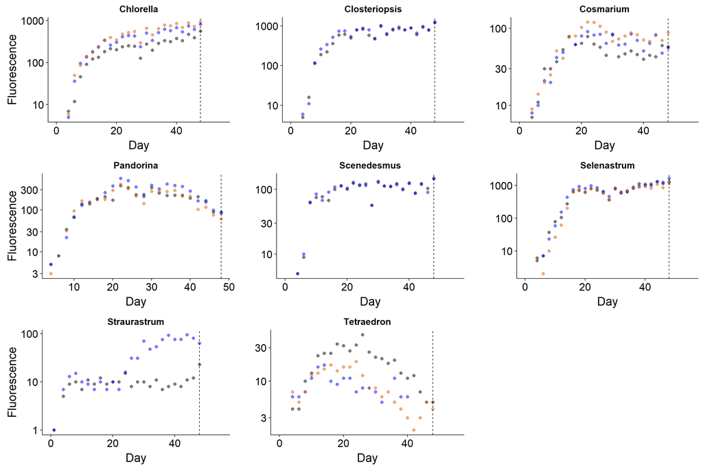

```r
S6.S8.Figure<-ggplot(Trmt.S6.S8,aes(x=Day,y=F,colour=Rep))+
  geom_point(alpha=0.5, size = 2)+
  scale_y_log10()+
  xlim(c(0,55))+
  xlab("Day")+
  ylab("")+
  xlim(c(0,55))+
  theme(plot.title = element_text(hjust = 0.5),legend.text.align = 0,legend.key=element_rect(fill=NA),panel.grid.major = element_blank(), panel.grid.minor = element_blank(),panel.background = element_blank(), axis.line = element_line(colour = "black"),axis.text=element_text(size = 16),axis.title=element_text(size=18,face="plain"),legend.title=element_text(size=16),legend.text=element_text(size=16))+
  scale_color_manual(guide=FALSE,values=c("black","blue","#D55E00"))+
  geom_vline(xintercept=48,linetype='dashed')+
  ggtitle("Selenastrum & Tetraedron")

S7.S8.Figure<-ggplot(Trmt.S7.S8,aes(x=Day,y=F,colour=Rep))+
  geom_point(alpha=0.5, size = 2)+
  scale_y_log10()+
  xlab("Day")+
  ylab("Fluorescence")+
  xlim(c(0,55))+
  theme(plot.title = element_text(hjust = 0.5),legend.text.align = 0,legend.key=element_rect(fill=NA),panel.grid.major = element_blank(), panel.grid.minor = element_blank(),panel.background = element_blank(), axis.line = element_line(colour = "black"),axis.text=element_text(size = 16),axis.title=element_text(size=18,face="plain"),legend.title=element_text(size=16),legend.text=element_text(size=16))+
  scale_color_manual(guide=FALSE,values=c("black","blue","#D55E00"))+
  geom_vline(xintercept=48,linetype='dashed')+
  ggtitle("Staurastrum & Tetraedron")

Figure.S5.part.1<-grid.arrange(S1.M.Figure,S2.M.Figure,S3.M.Figure,S4.M.Figure,S5.M.Figure,S6.M.Figure,S7.M.Figure,S8.M.Figure)
```

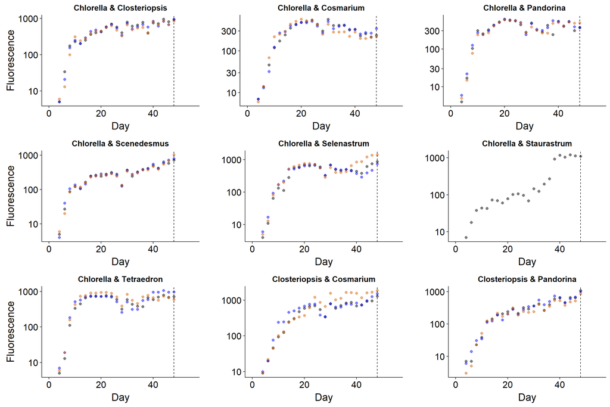

```r
Figure.S5.part.2<-grid.arrange(S1.S2.Figure,S1.S3.Figure,S1.S4.Figure,S1.S5.Figure,S1.S6.Figure,S1.S7.Figure,S1.S8.Figure,S2.S3.Figure,S2.S4.Figure,ncol=3)
```

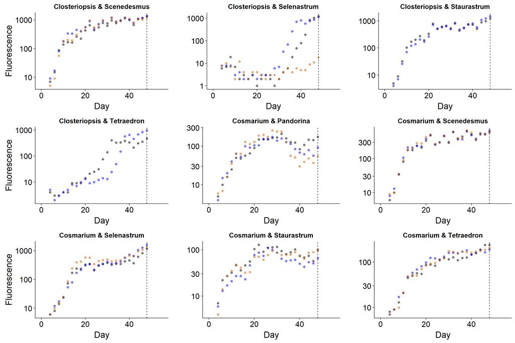

```r
Figure.S5.part.3<-grid.arrange(S2.S5.Figure,S2.S6.Figure,S2.S7.Figure,S2.S8.Figure,S3.S4.Figure,S3.S5.Figure,S3.S6.Figure,S3.S7.Figure,S3.S8.Figure,ncol=3)
```

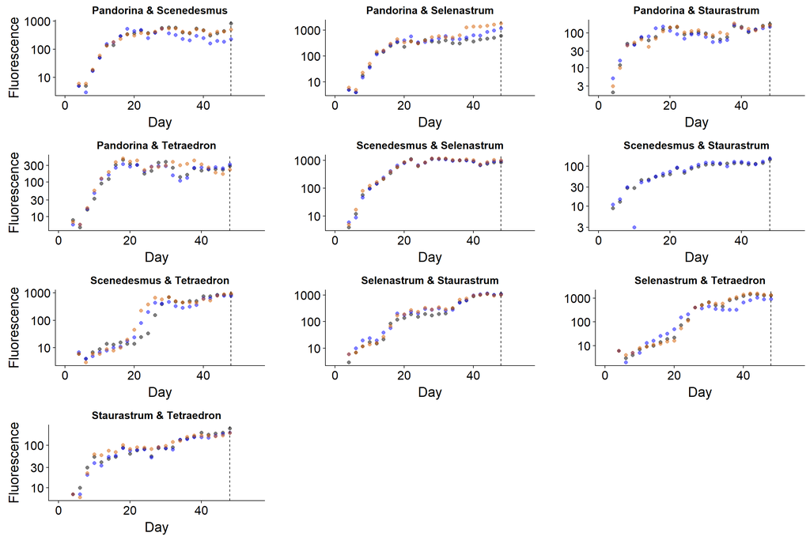

```r
Figure.S5.part.4<-grid.arrange(S4.S5.Figure,S4.S6.Figure,S4.S7.Figure,S4.S8.Figure,S5.S6.Figure,S5.S7.Figure,S5.S8.Figure,S6.S7.Figure,S6.S8.Figure,S7.S8.Figure,ncol=3)
```

Figure S6 Growth curves of each study species in COMBO versus Soil Water Medium illustrates positive growth of each species in COMBO. Each curve is the average of 8 replicates inoculated into medium at 1000 cells/mL in 48-well plates incubated in 16:8h light chamber.

```r
data<-read.csv("C:/Users/Sara/Desktop/Differential Expression by Basti/Media Comparisons.csv")
head(data)
```

```
##   Kinetic.read Time Media          F                 Species
## 1         0.00    0 COMBO  0.4285714 Pandorina charkowiensis
## 2         0.98    1 COMBO  2.1428571 Pandorina charkowiensis
## 3         1.99    2 COMBO  2.7142857 Pandorina charkowiensis
## 4         2.98    3 COMBO  4.7142857 Pandorina charkowiensis
## 5         3.97    4 COMBO  7.0000000 Pandorina charkowiensis
## 6         4.98    5 COMBO 10.1428571 Pandorina charkowiensis
```

```r
levels(data$Media)
```

```
## [1] "BOLD"  "COMBO" "SWM"
```

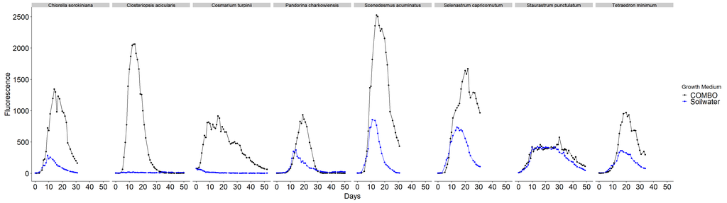

```r
data<-data[!(data$Media=="BOLD"),]
Figure.S6<-ggplot(data,aes(Kinetic.read,F,colour=Media))+
  geom_point(aes())+
  facet_grid(. ~ Species)+
  geom_line(aes(group = Media))+
  xlab("Days")+
  ylab("Fluorescence")+
  scale_color_manual(name="Growth Medium",values=c("black","blue"),labels=c("COMBO","Soilwater"))+
  theme(legend.text.align = 0,legend.title.align=0.5,legend.key=element_rect(fill=NA),panel.grid.major = element_blank(), panel.grid.minor = element_blank(),panel.background = element_blank(), axis.line = element_line(colour = "black"),axis.text=element_text(size = 18),axis.title=element_text(size=18,face="plain"),legend.text=element_text(size=18))
Figure.S6
```

Section 6: Biculture growing treatment frequently altered expression of genes regulating photosynthesis and nutrient assimilation.